# Анализ рынка недвижимости. Исследование объявлений о продаже квартир в Санкт-Петербурге.

Нам предоставлены данные сервиса Яндекс.Недвижимость — архив объявлений о продаже квартир в Санкт-Петербурге и соседних населённых пунктах за несколько лет. Нужно научиться определять рыночную стоимость объектов недвижимости. Задача — установить параметры. Это поможет построить автоматизированную систему,отслеживающую аномалии и мошенническую деятельность.

По каждой квартире на продажу доступны два вида данных. Первые вписаны пользователем, вторые получены автоматически на основе картографических данных. Например, расстояние до центра, аэропорта, ближайшего парка и водоёма.

```python
import pandas as pd
import matplotlib.pyplot as plt
import warnings
warnings.filterwarnings('ignore')
```

## Изучение данных из файла

```python
data=pd.read_csv('real_estate_data.csv', sep='\t')
data.info()
data.head(10)
```

```
<class 'pandas.core.frame.DataFrame'>
RangeIndex: 23699 entries, 0 to 23698
Data columns (total 22 columns):
 #   Column                Non-Null Count  Dtype
---  ------                --------------  -----
 0   total_images          23699 non-null  int64
 1   last_price            23699 non-null  float64
 2   total_area            23699 non-null  float64
 3   first_day_exposition  23699 non-null  object
 4   rooms                 23699 non-null  int64
 5   ceiling_height        14504 non-null  float64
 6   floors_total          23613 non-null  float64
 7   living_area           21796 non-null  float64
 8   floor                 23699 non-null  int64
 9   is_apartment          2775 non-null   object
 10  studio                23699 non-null  bool
 11  open_plan             23699 non-null  bool
 12  kitchen_area          21421 non-null  float64
 13  balcony               12180 non-null  float64
 14  locality_name         23650 non-null  object
 15  airports_nearest      18157 non-null  float64
 16  cityCenters_nearest   18180 non-null  float64
 17  parks_around3000      18181 non-null  float64
 18  parks_nearest         8079 non-null   float64
 19  ponds_around3000      18181 non-null  float64
 20  ponds_nearest         9110 non-null   float64
 21  days_exposition       20518 non-null  float64
dtypes: bool(2), float64(14), int64(3), object(3)
memory usage: 3.7+ MB
```

|  | total_images | last_price | total_area | first_day_exposition | rooms | ceiling_height | floors_total | living_area | floor | is_apartment | ... | kitchen_area | balcony | locality_name | airports_nearest | cityCenters_nearest | parks_around3000 | parks_nearest | ponds_around3000 | ponds_nearest | days_exposition |
| --- | --- | --- | --- | --- | --- | --- | --- | --- | --- | --- | --- | --- | --- | --- | --- | --- | --- | --- | --- | --- | --- |
| 0 | 20 | 13000000.0 | 108.00 | 2019-03-07T00:00:00 | 3 | 2.70 | 16.0 | 51.00 | 8 | NaN | ... | 25.00 | NaN | Санкт-Петербург | 18863.0 | 16028.0 | 1.0 | 482.0 | 2.0 | 755.0 | NaN |
| 1 | 7 | 3350000.0 | 40.40 | 2018-12-04T00:00:00 | 1 | NaN | 11.0 | 18.60 | 1 | NaN | ... | 11.00 | 2.0 | посёлок Шушары | 12817.0 | 18603.0 | 0.0 | NaN | 0.0 | NaN | 81.0 |
| 2 | 10 | 5196000.0 | 56.00 | 2015-08-20T00:00:00 | 2 | NaN | 5.0 | 34.30 | 4 | NaN | ... | 8.30 | 0.0 | Санкт-Петербург | 21741.0 | 13933.0 | 1.0 | 90.0 | 2.0 | 574.0 | 558.0 |
| 3 | 0 | 64900000.0 | 159.00 | 2015-07-24T00:00:00 | 3 | NaN | 14.0 | NaN | 9 | NaN | ... | NaN | 0.0 | Санкт-Петербург | 28098.0 | 6800.0 | 2.0 | 84.0 | 3.0 | 234.0 | 424.0 |
| 4 | 2 | 10000000.0 | 100.00 | 2018-06-19T00:00:00 | 2 | 3.03 | 14.0 | 32.00 | 13 | NaN | ... | 41.00 | NaN | Санкт-Петербург | 31856.0 | 8098.0 | 2.0 | 112.0 | 1.0 | 48.0 | 121.0 |
| 5 | 10 | 2890000.0 | 30.40 | 2018-09-10T00:00:00 | 1 | NaN | 12.0 | 14.40 | 5 | NaN | ... | 9.10 | NaN | городской посёлок Янино-1 | NaN | NaN | NaN | NaN | NaN | NaN | 55.0 |
| 6 | 6 | 3700000.0 | 37.30 | 2017-11-02T00:00:00 | 1 | NaN | 26.0 | 10.60 | 6 | NaN | ... | 14.40 | 1.0 | посёлок Парголово | 52996.0 | 19143.0 | 0.0 | NaN | 0.0 | NaN | 155.0 |
| 7 | 5 | 7915000.0 | 71.60 | 2019-04-18T00:00:00 | 2 | NaN | 24.0 | NaN | 22 | NaN | ... | 18.90 | 2.0 | Санкт-Петербург | 23982.0 | 11634.0 | 0.0 | NaN | 0.0 | NaN | NaN |
| 8 | 20 | 2900000.0 | 33.16 | 2018-05-23T00:00:00 | 1 | NaN | 27.0 | 15.43 | 26 | NaN | ... | 8.81 | NaN | посёлок Мурино | NaN | NaN | NaN | NaN | NaN | NaN | 189.0 |
| 9 | 18 | 5400000.0 | 61.00 | 2017-02-26T00:00:00 | 3 | 2.50 | 9.0 | 43.60 | 7 | NaN | ... | 6.50 | 2.0 | Санкт-Петербург | 50898.0 | 15008.0 | 0.0 | NaN | 0.0 | NaN | 289.0 |

10 rows × 22 columns

Таблица с информацией из объявлений о продаже квартир содержит 23699 строк и 22 столбца с данными. Два столбца содержат булевы значения, 3 - строковые данные, 3- целочисленные значения и 14 - вещественные значения. Кроме того в 14 из 22 столбцов таблицы имеются пропущенные значения.

Столбец `first_day_exposition`, содержащий дату публикации объявления, записан в строковом формате.

Столбец `is_apartment`, который, по описанию, должен состоять из значений булева типа, также содержит данные строкового формата.

При выводе на экран первых 10 строк таблицы можно заметить следующие проблемы, кроме незаполненных данных:

- в столбцах содержащих информацию о парках и водоемах есть два варианта пропусков либо незаполненное значение, либо нулевой (что при заполнении расстояния до ближайшего парка или водоема некорректно).

Посмотрим на данные с помощью метода `describe`

```python
data.describe().T
```

|  | count | mean | std | min | 25% | 50% | 75% | max |
| --- | --- | --- | --- | --- | --- | --- | --- | --- |
| total_images | 23699.0 | 9.858475e+00 | 5.682529e+00 | 0.0 | 6.00 | 9.00 | 14.0 | 50.0 |
| last_price | 23699.0 | 6.541549e+06 | 1.088701e+07 | 12190.0 | 3400000.00 | 4650000.00 | 6800000.0 | 763000000.0 |
| total_area | 23699.0 | 6.034865e+01 | 3.565408e+01 | 12.0 | 40.00 | 52.00 | 69.9 | 900.0 |
| rooms | 23699.0 | 2.070636e+00 | 1.078405e+00 | 0.0 | 1.00 | 2.00 | 3.0 | 19.0 |
| ceiling_height | 14504.0 | 2.771499e+00 | 1.261056e+00 | 1.0 | 2.52 | 2.65 | 2.8 | 100.0 |
| floors_total | 23613.0 | 1.067382e+01 | 6.597173e+00 | 1.0 | 5.00 | 9.00 | 16.0 | 60.0 |
| living_area | 21796.0 | 3.445785e+01 | 2.203045e+01 | 2.0 | 18.60 | 30.00 | 42.3 | 409.7 |
| floor | 23699.0 | 5.892358e+00 | 4.885249e+00 | 1.0 | 2.00 | 4.00 | 8.0 | 33.0 |
| kitchen_area | 21421.0 | 1.056981e+01 | 5.905438e+00 | 1.3 | 7.00 | 9.10 | 12.0 | 112.0 |
| balcony | 12180.0 | 1.150082e+00 | 1.071300e+00 | 0.0 | 0.00 | 1.00 | 2.0 | 5.0 |
| airports_nearest | 18157.0 | 2.879367e+04 | 1.263088e+04 | 0.0 | 18585.00 | 26726.00 | 37273.0 | 84869.0 |
| cityCenters_nearest | 18180.0 | 1.419128e+04 | 8.608386e+03 | 181.0 | 9238.00 | 13098.50 | 16293.0 | 65968.0 |
| parks_around3000 | 18181.0 | 6.114075e-01 | 8.020736e-01 | 0.0 | 0.00 | 0.00 | 1.0 | 3.0 |
| parks_nearest | 8079.0 | 4.908046e+02 | 3.423180e+02 | 1.0 | 288.00 | 455.00 | 612.0 | 3190.0 |
| ponds_around3000 | 18181.0 | 7.702547e-01 | 9.383456e-01 | 0.0 | 0.00 | 1.00 | 1.0 | 3.0 |
| ponds_nearest | 9110.0 | 5.179809e+02 | 2.777206e+02 | 13.0 | 294.00 | 502.00 | 729.0 | 1344.0 |
| days_exposition | 20518.0 | 1.808886e+02 | 2.197280e+02 | 1.0 | 45.00 | 95.00 | 232.0 | 1580.0 |

### Вывод

Предварительно можно утверждать, что данных достаточно для проведения исследования. Однако в большом количестве столбцов имеются пропущенные данные (в 14 из 22). Также, некоторые столбцы содержат некорректные, явно ошибочные значения. Имеется несколько столбцов с очень большим разбросом показателей.

Для проведения исследования необходимо по возможности заполнить пропущенные значения, привести столбец `is_apartment` к булеву формату, а столбец `first_day_exposition` к типу данных 'datetime'. Еще можно привести столбцы `floors_total`, `balcony`, `parks_around3000`, `ponds_around3000`, `days_exposition` к целочисленному формату.

## Предобработка данных

### Столбец `rooms`

В этом столбце нет пропущенных значений, но есть количество комнат 0. посмотрим на сколько их много и как выглядят объявления с этим показателем.

```python
print ('Количество объявлений с квартирами где 0 комнат:', len(data.query('rooms == 0')))
data.query('rooms == 0').head(10)
```

```
Количество объявлений с квартирами где 0 комнат: 197
```

|  | total_images | last_price | total_area | first_day_exposition | rooms | ceiling_height | floors_total | living_area | floor | is_apartment | ... | kitchen_area | balcony | locality_name | airports_nearest | cityCenters_nearest | parks_around3000 | parks_nearest | ponds_around3000 | ponds_nearest | days_exposition |
| --- | --- | --- | --- | --- | --- | --- | --- | --- | --- | --- | --- | --- | --- | --- | --- | --- | --- | --- | --- | --- | --- |
| 144 | 1 | 2450000.0 | 27.00 | 2017-03-30T00:00:00 | 0 | NaN | 24.0 | 15.50 | 2 | NaN | ... | NaN | 2.0 | посёлок Мурино | NaN | NaN | NaN | NaN | NaN | NaN | 181.0 |
| 349 | 4 | 2320000.0 | 25.00 | 2017-09-27T00:00:00 | 0 | NaN | 14.0 | 17.00 | 1 | NaN | ... | NaN | 0.0 | деревня Кудрово | NaN | NaN | NaN | NaN | NaN | NaN | 45.0 |
| 440 | 8 | 2480000.0 | 27.11 | 2018-03-12T00:00:00 | 0 | NaN | 17.0 | 24.75 | 4 | NaN | ... | NaN | 2.0 | Санкт-Петербург | 38171.0 | 15015.0 | 0.0 | NaN | 2.0 | 982.0 | 64.0 |
| 508 | 0 | 3375000.0 | 34.40 | 2017-03-28T00:00:00 | 0 | NaN | 26.0 | 24.30 | 19 | NaN | ... | NaN | 1.0 | посёлок Парголово | 53115.0 | 19292.0 | 0.0 | NaN | 1.0 | 593.0 | 430.0 |
| 608 | 2 | 1850000.0 | 25.00 | 2019-02-20T00:00:00 | 0 | NaN | 10.0 | NaN | 7 | NaN | ... | NaN | NaN | посёлок Шушары | NaN | NaN | NaN | NaN | NaN | NaN | 29.0 |
| 697 | 12 | 2500000.0 | 24.10 | 2017-12-01T00:00:00 | 0 | 2.75 | 25.0 | 17.50 | 21 | NaN | ... | NaN | NaN | деревня Кудрово | NaN | NaN | NaN | NaN | NaN | NaN | 201.0 |
| 716 | 5 | 1500000.0 | 17.00 | 2017-06-07T00:00:00 | 0 | 2.70 | 9.0 | 12.00 | 1 | NaN | ... | NaN | 0.0 | посёлок Шушары | 18654.0 | 29846.0 | 0.0 | NaN | 0.0 | NaN | 40.0 |
| 780 | 9 | 2600000.0 | 26.10 | 2018-02-20T00:00:00 | 0 | NaN | 18.0 | NaN | 8 | NaN | ... | NaN | 1.0 | посёлок Мурино | NaN | NaN | NaN | NaN | NaN | NaN | 45.0 |
| 839 | 14 | 1900000.0 | 35.00 | 2017-04-14T00:00:00 | 0 | 2.70 | 5.0 | 15.00 | 3 | False | ... | NaN | 1.0 | поселок Новый Свет | NaN | NaN | NaN | NaN | NaN | NaN | 7.0 |
| 946 | 5 | 2200000.0 | 23.00 | 2016-09-27T00:00:00 | 0 | NaN | 27.0 | 18.00 | 7 | NaN | ... | NaN | 2.0 | посёлок Мурино | NaN | NaN | NaN | NaN | NaN | NaN | 483.0 |

10 rows × 22 columns

Можно предположить, что количество комнат 0 соответствует однокомнатным квартирам студиям Проверим.

```python
data.query('rooms == 0')['studio'].value_counts()
```

```
True     138
False     59
Name: studio, dtype: int64
```

138 из 197 квартир действительно студии. Посмотрим сколько всего квартир студий в объявлениях

```python
data['studio'].value_counts()
```

```
False    23550
True       149
Name: studio, dtype: int64
```

Посмотрим как обозначено число комнат в других объявлениях с квартирами-студиями

```python
data.query('rooms != 0 and studio == True')
```

|  | total_images | last_price | total_area | first_day_exposition | rooms | ceiling_height | floors_total | living_area | floor | is_apartment | ... | kitchen_area | balcony | locality_name | airports_nearest | cityCenters_nearest | parks_around3000 | parks_nearest | ponds_around3000 | ponds_nearest | days_exposition |
| --- | --- | --- | --- | --- | --- | --- | --- | --- | --- | --- | --- | --- | --- | --- | --- | --- | --- | --- | --- | --- | --- |
| 2389 | 5 | 2250000.0 | 25.41 | 2016-06-07T00:00:00 | 1 | NaN | 12.0 | 17.08 | 8 | False | ... | NaN | 2.0 | Санкт-Петербург | 14125.0 | 12921.0 | 2.0 | 328.0 | 2.0 | 485.0 | 26.0 |
| 3187 | 13 | 3800000.0 | 27.00 | 2016-05-17T00:00:00 | 1 | NaN | 14.0 | 18.00 | 8 | False | ... | NaN | 2.0 | Санкт-Петербург | 50348.0 | 16053.0 | 0.0 | NaN | 0.0 | NaN | 45.0 |
| 4180 | 4 | 4500000.0 | 34.00 | 2016-04-25T00:00:00 | 1 | 2.8 | 10.0 | 21.00 | 10 | False | ... | NaN | 2.0 | Санкт-Петербург | 23609.0 | 5299.0 | 0.0 | NaN | 1.0 | 433.0 | 62.0 |
| 8683 | 10 | 3500000.0 | 32.50 | 2016-05-05T00:00:00 | 1 | 3.0 | 23.0 | 29.90 | 11 | False | ... | NaN | 2.0 | Санкт-Петербург | 34967.0 | 14640.0 | 0.0 | NaN | 1.0 | 564.0 | 45.0 |
| 11026 | 1 | 2800000.0 | 28.00 | 2016-05-04T00:00:00 | 1 | NaN | 26.0 | 19.00 | 6 | False | ... | NaN | 2.0 | посёлок Парголово | 53511.0 | 19687.0 | 0.0 | NaN | 0.0 | NaN | 45.0 |
| 12935 | 10 | 2200000.0 | 31.00 | 2016-05-15T00:00:00 | 1 | 2.5 | 8.0 | 22.30 | 5 | False | ... | NaN | 1.0 | Никольское | NaN | NaN | NaN | NaN | NaN | NaN | 44.0 |
| 15142 | 2 | 2700000.0 | 30.00 | 2016-05-10T00:00:00 | 1 | NaN | 21.0 | 26.00 | 6 | False | ... | NaN | 0.0 | деревня Кудрово | NaN | NaN | NaN | NaN | NaN | NaN | 55.0 |
| 18732 | 4 | 2400000.0 | 22.00 | 2016-05-06T00:00:00 | 1 | NaN | 10.0 | 15.00 | 6 | NaN | ... | NaN | 0.0 | деревня Кудрово | NaN | NaN | NaN | NaN | NaN | NaN | 45.0 |
| 20086 | 0 | 1550000.0 | 22.00 | 2016-05-11T00:00:00 | 1 | 2.7 | 15.0 | 10.94 | 14 | False | ... | NaN | 2.0 | Никольское | NaN | NaN | NaN | NaN | NaN | NaN | 45.0 |
| 21702 | 9 | 2349000.0 | 23.40 | 2016-05-19T00:00:00 | 1 | 2.7 | 20.0 | 16.00 | 8 | False | ... | NaN | 1.0 | деревня Новое Девяткино | NaN | NaN | NaN | NaN | NaN | NaN | 34.0 |
| 22652 | 5 | 2650000.0 | 26.00 | 2015-06-24T00:00:00 | 1 | NaN | 14.0 | 15.00 | 11 | False | ... | NaN | 0.0 | поселок Мурино | NaN | NaN | NaN | NaN | NaN | NaN | 373.0 |

11 rows × 22 columns

В объявлениях, где количество комнат 0 соответствует квартире-студии, можем 0 заменить на 1

Сделаем замену и проверим результат.

```python
data.loc[(data['rooms'] == 0) & (data['studio'] == True),'rooms'] = 1

print ('Количество объявлений с квартирами где 0 комнат:', len(data.query('rooms == 0')))
```

```
Количество объявлений с квартирами где 0 комнат: 59
```

Проверим оставшиеся квартиры с 0 комнат на открытую планировку

```python
data.query('rooms == 0')['open_plan'].value_counts()
```

```
True    59
Name: open_plan, dtype: int64
```

Остальные квартиры с нулевым количеством комнат - это квартиры со свободной планировкой. Посмотрим сколько их всего в таблице.

```python
data['open_plan'].value_counts()
```

```
False    23632
True        67
Name: open_plan, dtype: int64
```

Посмотрим как обозначено количество комнат в остальных объявлениях с открытой планировкой.

```python
data.query('rooms != 0 and open_plan == True')
```

|  | total_images | last_price | total_area | first_day_exposition | rooms | ceiling_height | floors_total | living_area | floor | is_apartment | ... | kitchen_area | balcony | locality_name | airports_nearest | cityCenters_nearest | parks_around3000 | parks_nearest | ponds_around3000 | ponds_nearest | days_exposition |
| --- | --- | --- | --- | --- | --- | --- | --- | --- | --- | --- | --- | --- | --- | --- | --- | --- | --- | --- | --- | --- | --- |
| 1379 | 3 | 6000000.0 | 44.2 | 2015-11-10T00:00:00 | 1 | NaN | 25.0 | 17.4 | 23 | False | ... | NaN | 1.0 | Санкт-Петербург | 10663.0 | 12738.0 | 0.0 | NaN | 0.0 | NaN | 231.0 |
| 5668 | 9 | 3550000.0 | 36.7 | 2016-04-25T00:00:00 | 1 | 2.75 | 16.0 | 17.8 | 2 | False | ... | NaN | 2.0 | деревня Кудрово | NaN | NaN | NaN | NaN | NaN | NaN | 61.0 |
| 8861 | 13 | 5500000.0 | 64.5 | 2015-11-13T00:00:00 | 3 | 3.00 | 5.0 | 48.0 | 2 | False | ... | NaN | 0.0 | Санкт-Петербург | 20040.0 | 2621.0 | 2.0 | 205.0 | 2.0 | 204.0 | 229.0 |
| 9063 | 6 | 3800000.0 | 39.0 | 2016-05-19T00:00:00 | 1 | NaN | 17.0 | 30.0 | 1 | False | ... | NaN | 0.0 | Санкт-Петербург | 36721.0 | 13635.0 | 0.0 | NaN | 0.0 | NaN | 45.0 |
| 12760 | 0 | 3350000.0 | 51.0 | 2015-01-22T00:00:00 | 2 | 2.50 | 12.0 | 30.0 | 10 | NaN | ... | NaN | 2.0 | Коммунар | NaN | NaN | NaN | NaN | NaN | NaN | 521.0 |
| 14017 | 13 | 3990000.0 | 59.0 | 2016-03-29T00:00:00 | 3 | 2.50 | 9.0 | 37.6 | 3 | False | ... | NaN | 1.0 | Колпино | 27820.0 | 33606.0 | 0.0 | NaN | 1.0 | 705.0 | 81.0 |
| 17783 | 3 | 48763000.0 | 157.0 | 2016-04-01T00:00:00 | 5 | NaN | 11.0 | NaN | 5 | NaN | ... | NaN | 0.0 | Санкт-Петербург | 28399.0 | 7101.0 | 2.0 | 290.0 | 3.0 | 221.0 | 90.0 |
| 19796 | 1 | 12000000.0 | 97.2 | 2016-04-05T00:00:00 | 4 | 3.35 | 5.0 | 71.3 | 2 | False | ... | NaN | 0.0 | Санкт-Петербург | 24559.0 | 4811.0 | 0.0 | NaN | 0.0 | NaN | 89.0 |

8 rows × 22 columns

Здесь разное количество комнат в зависимости от общей площади квартиры. Разделение на комнаты в квартирах со свободной планировкой весьма условно.

Посмотрим площади оставшихся квартир с 0 комнат

```python
data.query('rooms == 0 and open_plan == True')['total_area'].sort_values().unique()
```

```
array([ 16.  ,  20.  ,  21.  ,  22.  ,  22.5 ,  23.  ,  23.06,  23.98,
        24.  ,  24.2 ,  25.  ,  25.2 ,  25.27,  25.41,  25.9 ,  26.  ,
        26.1 ,  26.8 ,  27.  ,  27.1 ,  27.3 ,  27.32,  27.5 ,  27.7 ,
        28.  ,  28.01,  28.05,  28.2 ,  28.3 ,  28.5 ,  29.  ,  30.  ,
        30.5 ,  31.  ,  31.1 ,  32.3 ,  34.  ,  34.4 ,  35.  ,  42.63,
       371.  ])
```

Как видно оставшиеся квартиры соответствуют по площади 1-комнатным, кроме варианта с площадью 371 кв м. Самая большая квартира со свободной планировкой, где заполнено количество комнат 157 кв м и это соответствует 5 комнатам. По аналогии количество комнат в квартире площадью 371 кв м определим как 12.

Заменим количество комнат 0 на 1 для квартир площадью до 43 квм и на 12 для квартир площадью 371 кв м и проверим результат

```python
data.loc[(data['rooms'] == 0) & (data['total_area'] < 43),'rooms'] = 1
data.loc[(data['rooms'] == 0) & (data['total_area'] == 371),'rooms'] = 12

print ('Количество объявлений с квартирами где 0 комнат:', len(data.query('rooms == 0')))
```

```
Количество объявлений с квартирами где 0 комнат: 0
```

### Столбец `locality_name`

Столбец `locality_name` содержит 49 незаполненных значений. Сложно оппределить чем их можно заполнить. Поскольку это всего лишь 0,2% выборки возможно удалить строки с незаполненными значениями.

```python
print('Пропущенные значения до', data['locality_name'].isna().sum())
print('Строк в таблице до', len(data))
data = data.dropna(subset=['locality_name']).reset_index(drop=True)
print('Пропущенные значения после', data['locality_name'].isna().sum())
print('Строк в таблице после', len(data))
```

```
Пропущенные значения до 49
Строк в таблице до 23699
Пропущенные значения после 0
Строк в таблице после 23650
```

Проверим на неявные дубликаты Посмотрим все уникальные значения

```python
data['locality_name'].sort_values().unique()
```

```
array(['Бокситогорск', 'Волосово', 'Волхов', 'Всеволожск', 'Выборг',
       'Высоцк', 'Гатчина', 'Зеленогорск', 'Ивангород', 'Каменногорск',
       'Кингисепп', 'Кириши', 'Кировск', 'Колпино', 'Коммунар',
       'Красное Село', 'Кронштадт', 'Кудрово', 'Лодейное Поле',
       'Ломоносов', 'Луга', 'Любань', 'Мурино', 'Никольское',
       'Новая Ладога', 'Отрадное', 'Павловск', 'Петергоф', 'Пикалёво',
       'Подпорожье', 'Приморск', 'Приозерск', 'Пушкин', 'Санкт-Петербург',
       'Светогорск', 'Сертолово', 'Сестрорецк', 'Сланцы', 'Сосновый Бор',
       'Сясьстрой', 'Тихвин', 'Тосно', 'Шлиссельбург',
       'городской поселок Большая Ижора', 'городской поселок Янино-1',
       'городской посёлок Будогощь', 'городской посёлок Виллози',
       'городской посёлок Лесогорский', 'городской посёлок Мга',
       'городской посёлок Назия', 'городской посёлок Новоселье',
       'городской посёлок Павлово', 'городской посёлок Рощино',
       'городской посёлок Свирьстрой', 'городской посёлок Советский',
       'городской посёлок Фёдоровское', 'городской посёлок Янино-1',
       'деревня Агалатово', 'деревня Аро', 'деревня Батово',
       'деревня Бегуницы', 'деревня Белогорка', 'деревня Большая Вруда',
       'деревня Большая Пустомержа', 'деревня Большие Колпаны',
       'деревня Большое Рейзино', 'деревня Большой Сабск', 'деревня Бор',
       'деревня Борисова Грива', 'деревня Ваганово', 'деревня Вартемяги',
       'деревня Вахнова Кара', 'деревня Выскатка', 'деревня Гарболово',
       'деревня Глинка', 'деревня Горбунки', 'деревня Гостилицы',
       'деревня Заклинье', 'деревня Заневка', 'деревня Зимитицы',
       'деревня Извара', 'деревня Иссад', 'деревня Калитино',
       'деревня Кальтино', 'деревня Камышовка', 'деревня Каськово',
       'деревня Келози', 'деревня Кипень', 'деревня Кисельня',
       'деревня Колтуши', 'деревня Коркино', 'деревня Котлы',
       'деревня Кривко', 'деревня Кудрово', 'деревня Кузьмолово',
       'деревня Курковицы', 'деревня Куровицы', 'деревня Куттузи',
       'деревня Лаврики', 'деревня Лаголово', 'деревня Лампово',
       'деревня Лесколово', 'деревня Лопухинка', 'деревня Лупполово',
       'деревня Малая Романовка', 'деревня Малое Верево',
       'деревня Малое Карлино', 'деревня Малые Колпаны',
       'деревня Мануйлово', 'деревня Меньково', 'деревня Мины',
       'деревня Мистолово', 'деревня Ненимяки', 'деревня Нижние Осельки',
       'деревня Нижняя', 'деревня Низино', 'деревня Новое Девяткино',
       'деревня Новолисино', 'деревня Нурма', 'деревня Оржицы',
       'деревня Парицы', 'деревня Пельгора', 'деревня Пеники',
       'деревня Пижма', 'деревня Пикколово', 'деревня Пудомяги',
```

[output cut: 96 more lines]

```
       'посёлок городского типа Тайцы', 'посёлок городского типа Токсово',
       'посёлок городского типа Ульяновка',
       'посёлок городского типа Форносово',
       'посёлок городского типа имени Морозова',
       'посёлок городского типа имени Свердлова',
       'посёлок при железнодорожной станции Вещево',
       'посёлок при железнодорожной станции Приветнинское',
       'посёлок станции Громово', 'посёлок станции Свирь',
       'садоводческое некоммерческое товарищество Лесная Поляна',
       'садовое товарищество Новая Ропша',
       'садовое товарищество Приладожский', 'садовое товарищество Рахья',
       'садовое товарищество Садко', 'село Копорье', 'село Никольское',
       'село Павлово', 'село Паша', 'село Путилово', 'село Рождествено',
       'село Русско-Высоцкое', 'село Старая Ладога', 'село Шум'],
      dtype=object)
```

Как видно названия населенных пунктов записаны по-разному (поселок с буквой е и ё, есть и городской и городского типа, есть названия без определения поселка или села и т.д.). Для исключения неявных дубликатов оставим только сами названия населенных пунктов.

```python
# функция для удаления лишних названий
def replace_locality_name(wrong_names):
        for wrong_name in wrong_names:
            data['locality_name'] = data['locality_name'].str.replace(wrong_name, '')


# список слов, которые нужно удалить из значений в столбце
duplicates = ['городской ','посёлок ', 'деревня ', 'коттеджный ', 'поселок ', 'городского типа ', 'станции ', 'при железнодорожной ', 'садоводческое некоммерческое ', 'садовое ', 'товарищество ', 'село ']

# вызов функции
replace_locality_name(duplicates)

# проверка результата
data['locality_name'].sort_values().unique()
```

```
array(['Агалатово', 'Александровская', 'Алексеевка', 'Аннино', 'Аро',
       'Барышево', 'Батово', 'Бегуницы', 'Белогорка', 'Белоостров',
       'Бокситогорск', 'Большая Вруда', 'Большая Ижора',
       'Большая Пустомержа', 'Большие Колпаны', 'Большое Рейзино',
       'Большой Сабск', 'Бор', 'Борисова Грива', 'Бугры', 'Будогощь',
       'Ваганово', 'Важины', 'Вартемяги', 'Вахнова Кара', 'Вещево',
       'Виллози', 'Вознесенье', 'Возрождение', 'Войсковицы', 'Войскорово',
       'Володарское', 'Волосово', 'Волхов', 'Всеволожск', 'Выборг',
       'Вырица', 'Выскатка', 'Высокоключевой', 'Высоцк', 'Гаврилово',
       'Гарболово', 'Гатчина', 'Гладкое', 'Глажево', 'Глебычево',
       'Глинка', 'Гончарово', 'Горбунки', 'Гостилицы', 'Громово',
       'Дзержинского', 'Дружная Горка', 'Дружноселье', 'Дубровка',
       'Елизаветино', 'Ефимовский', 'Жилгородок', 'Жилпосёлок', 'Житково',
       'Заводской', 'Заклинье', 'Заневка', 'Запорожское', 'Зеленогорск',
       'Зимитицы', 'Ивангород', 'Извара', 'Ильичёво', 'Иссад', 'Калитино',
       'Каложицы', 'Кальтино', 'Каменногорск', 'Камышовка', 'Каськово',
       'Келози', 'Кивеннапа Север', 'Кикерино', 'Кингисепп',
       'Кингисеппский', 'Кипень', 'Кириши', 'Кировск', 'Кирпичное',
       'Кисельня', 'Кобралово', 'Кобринское', 'Колпино', 'Колтуши',
       'Коммунар', 'Коммунары', 'Кондратьево', 'Копорье', 'Коркино',
       'Корнево', 'Коробицыно', 'Котельский', 'Котлы', 'Красная Долина',
       'Красное Село', 'Красносельское', 'Красный Бор', 'Кривко',
       'Кронштадт', 'Кудрово', 'Кузнечное', 'Кузьмолово', 'Кузьмоловский',
       'Курковицы', 'Куровицы', 'Куттузи', 'Лаврики', 'Лаголово',
       'Лампово', 'Лебяжье', 'Левашово', 'Ленинское', 'Лесколово',
       'Лесная Поляна', 'Лесное', 'Лесогорский', 'Лисий Нос',
       'Лодейное Поле', 'Ломоносов', 'Лопухинка', 'Луга', 'Лужайка',
       'Лукаши', 'Лупполово', 'Любань', 'Малая Романовка', 'Малое Верево',
       'Малое Карлино', 'Малые Колпаны', 'Мануйлово', 'Мга', 'Мельниково',
       'Меньково', 'Металлострой', 'Мины', 'Мистолово', 'Мичуринское',
       'Молодцово', 'Молодёжное', 'Мурино', 'Мыза-Ивановка', 'Назия',
       'Ненимяки', 'Нижние Осельки', 'Нижняя', 'Низино', 'Никольский',
       'Никольское', 'Новая Ладога', 'Новая Ропша', 'Новогорелово',
       'Новое Девяткино', 'Новолисино', 'Новоселье', 'Новый Свет',
       'Новый Учхоз', 'Нурма', 'Оредеж', 'Оржицы', 'Отрадное', 'Павлово',
       'Павловск', 'Пансионат Зелёный Бор', 'Парголово', 'Парицы', 'Паша',
       'Пельгора', 'Пеники', 'Первомайское', 'Перово', 'Песочный',
       'Петергоф', 'Петро-Славянка', 'Петровское', 'Пижма', 'Пикалёво',
       'Пикколово', 'Платформа 69-й километр', 'Плодовое', 'Плоское',
       'Победа', 'Подпорожье', 'Поляны', 'Понтонный', 'Почап', 'Починок',
```

[output cut: 9 more lines]

```
       'Синявино', 'Сланцы', 'Снегирёвка', 'Советский', 'Совхозный',
       'Сосново', 'Сосновый Бор', 'Старая', 'Старая Ладога',
       'Старая Малукса', 'Старая Пустошь', 'Старое Хинколово',
       'Старополье', 'Старосиверская', 'Старые Бегуницы', 'Стеклянный',
       'Стрельна', 'Суйда', 'Сумино', 'Суоранда', 'Суходолье', 'Счастье',
       'Сяськелево', 'Сясьстрой', 'Тайцы', 'Тарасово', 'Тельмана',
       'Терволово', 'Терпилицы', 'Тихвин', 'Тихковицы', 'Тойворово',
       'Токсово', 'Торковичи', 'Торосово', 'Торошковичи', 'Торфяное',
       'Тосно', 'Трубников Бор', 'Тёсово-4', 'Углово', 'Ульяновка',
       'Усть-Ижора', 'Усть-Луга', 'Ушаки', 'Фалилеево', 'Форносово',
       'Форт Красная Горка', 'Фёдоровское', 'Хапо-Ое', 'Хязельки',
       'Цвелодубово', 'Цвылёво', 'Чудской Бор', 'Шлиссельбург',
       'Шпаньково', 'Шугозеро', 'Шум', 'Шушары', 'Щеглово', 'Юкки',
       'Ялгино', 'Яльгелево', 'Ям-Тесово', 'Янино-1', 'имени Морозова',
       'имени Свердлова'], dtype=object)
```

**Success:** замечательно! избавились от всех скрытых дубликатов :)

### Столбец `ceiling_height`

Столбец `ceiling_height` содержит пропуски и некорректные значения. Посмотрим на все уникальные значения в столбце.

```python
data['ceiling_height'].sort_values().unique()
```

```
array([  1.  ,   1.2 ,   1.75,   2.  ,   2.2 ,   2.25,   2.3 ,   2.34,
         2.4 ,   2.45,   2.46,   2.47,   2.48,   2.49,   2.5 ,   2.51,
         2.52,   2.53,   2.54,   2.55,   2.56,   2.57,   2.58,   2.59,
         2.6 ,   2.61,   2.62,   2.63,   2.64,   2.65,   2.66,   2.67,
         2.68,   2.69,   2.7 ,   2.71,   2.72,   2.73,   2.74,   2.75,
         2.76,   2.77,   2.78,   2.79,   2.8 ,   2.81,   2.82,   2.83,
         2.84,   2.85,   2.86,   2.87,   2.88,   2.89,   2.9 ,   2.91,
         2.92,   2.93,   2.94,   2.95,   2.96,   2.97,   2.98,   2.99,
         3.  ,   3.01,   3.02,   3.03,   3.04,   3.05,   3.06,   3.07,
         3.08,   3.09,   3.1 ,   3.11,   3.12,   3.13,   3.14,   3.15,
         3.16,   3.17,   3.18,   3.2 ,   3.21,   3.22,   3.23,   3.24,
         3.25,   3.26,   3.27,   3.28,   3.29,   3.3 ,   3.31,   3.32,
         3.33,   3.34,   3.35,   3.36,   3.37,   3.38,   3.39,   3.4 ,
         3.42,   3.43,   3.44,   3.45,   3.46,   3.47,   3.48,   3.49,
         3.5 ,   3.51,   3.52,   3.53,   3.54,   3.55,   3.56,   3.57,
         3.58,   3.59,   3.6 ,   3.62,   3.63,   3.65,   3.66,   3.67,
         3.68,   3.69,   3.7 ,   3.75,   3.76,   3.78,   3.8 ,   3.82,
         3.83,   3.84,   3.85,   3.86,   3.87,   3.88,   3.9 ,   3.93,
         3.95,   3.98,   4.  ,   4.06,   4.1 ,   4.14,   4.15,   4.19,
         4.2 ,   4.25,   4.3 ,   4.37,   4.4 ,   4.45,   4.5 ,   4.65,
         4.7 ,   4.8 ,   4.9 ,   5.  ,   5.2 ,   5.3 ,   5.5 ,   5.6 ,
         5.8 ,   6.  ,   8.  ,   8.3 ,  10.3 ,  14.  ,  20.  ,  22.6 ,
        24.  ,  25.  ,  26.  ,  27.  ,  27.5 ,  32.  , 100.  ,    nan])
```

В значениях высоты потолка от 20 до 32 вполне вероятно пропущена точка - десятичный разделитель. Заменим эти значения на такие же, разделенные на 10. С высотой потолков 1 и 100 м пока ничего делать не будем, не ясно чем ее заменить.

```python
data.loc[(data['ceiling_height'] >= 20) & (data['ceiling_height'] < 35), 'ceiling_height'] = (
    data.loc[(data['ceiling_height'] >= 20) & (data['ceiling_height'] < 35), 'ceiling_height'] / 10
)

data['ceiling_height'].sort_values().unique()
```

```
array([  1.  ,   1.2 ,   1.75,   2.  ,   2.2 ,   2.25,   2.26,   2.3 ,
         2.34,   2.4 ,   2.45,   2.46,   2.47,   2.48,   2.49,   2.5 ,
         2.51,   2.52,   2.53,   2.54,   2.55,   2.56,   2.57,   2.58,
         2.59,   2.6 ,   2.61,   2.62,   2.63,   2.64,   2.65,   2.66,
         2.67,   2.68,   2.69,   2.7 ,   2.71,   2.72,   2.73,   2.74,
         2.75,   2.76,   2.77,   2.78,   2.79,   2.8 ,   2.81,   2.82,
         2.83,   2.84,   2.85,   2.86,   2.87,   2.88,   2.89,   2.9 ,
         2.91,   2.92,   2.93,   2.94,   2.95,   2.96,   2.97,   2.98,
         2.99,   3.  ,   3.01,   3.02,   3.03,   3.04,   3.05,   3.06,
         3.07,   3.08,   3.09,   3.1 ,   3.11,   3.12,   3.13,   3.14,
         3.15,   3.16,   3.17,   3.18,   3.2 ,   3.21,   3.22,   3.23,
         3.24,   3.25,   3.26,   3.27,   3.28,   3.29,   3.3 ,   3.31,
         3.32,   3.33,   3.34,   3.35,   3.36,   3.37,   3.38,   3.39,
         3.4 ,   3.42,   3.43,   3.44,   3.45,   3.46,   3.47,   3.48,
         3.49,   3.5 ,   3.51,   3.52,   3.53,   3.54,   3.55,   3.56,
         3.57,   3.58,   3.59,   3.6 ,   3.62,   3.63,   3.65,   3.66,
         3.67,   3.68,   3.69,   3.7 ,   3.75,   3.76,   3.78,   3.8 ,
         3.82,   3.83,   3.84,   3.85,   3.86,   3.87,   3.88,   3.9 ,
         3.93,   3.95,   3.98,   4.  ,   4.06,   4.1 ,   4.14,   4.15,
         4.19,   4.2 ,   4.25,   4.3 ,   4.37,   4.4 ,   4.45,   4.5 ,
         4.65,   4.7 ,   4.8 ,   4.9 ,   5.  ,   5.2 ,   5.3 ,   5.5 ,
         5.6 ,   5.8 ,   6.  ,   8.  ,   8.3 ,  10.3 ,  14.  , 100.  ,
          nan])
```

Заменим незаполненные значения медианныем показателем. Поскольку в некоторых населенных пунктах может быть более старая или новая застройка с разной высотой потолков, проведем замену на медианный показатель с учетом населенного пункта. Если этот показатель будет считаться некорректно (объявлений по населенному пункту мало и все без указания высот потолков) заменим пропуск на медиану в целом по выборке.

```python
print ('Медианная высота поталков по таблице:', data['ceiling_height'].median())
```

```
Медианная высота поталков по таблице: 2.65
```

```python
print('Пропущенные значения до', data['ceiling_height'].isna().sum())

for name in data['locality_name'].unique():

    # условие если все значение высоты потолков по населенному пункту пропущены
    if data.loc[data['locality_name'] == name, 'ceiling_height'].isna().sum() == len(data.loc[data['locality_name'] == name]):

        print ('Пропущенные значения высоты потолков в', name, 'заменим медианой по выборке', 2.65)
        # заменяет пропущенное значение на медианное по таблице
        data.loc[(data['ceiling_height'].isna()) & (data['locality_name'] == name), 'ceiling_height'] = 2.65


    else:
        # находит медианное значение для каждого населенного пункта
        median= data.loc[data['locality_name'] == name, 'ceiling_height'].median()

        print(name, median)
        # заменяет пропущенное значение на медианное в соответствии с населенным пунктом
        data.loc[(data['ceiling_height'].isna()) & (data['locality_name'] == name), 'ceiling_height'] = median



print('Пропущенные значения после', data['ceiling_height'].isna().sum())
```

```
Пропущенные значения до 9160
Санкт-Петербург 2.7
Шушары 2.63
Янино-1 2.65
Парголово 2.64
Мурино 2.7
Ломоносов 2.55
Сертолово 2.6
Петергоф 2.55
Пушкин 2.6
Кудрово 2.75
Коммунар 2.5599999999999996
Колпино 2.5
Красный Бор 2.5
Гатчина 2.55
Фёдоровское 2.6
Выборг 2.55
Кронштадт 2.55
Кировск 2.5
Новое Девяткино 2.7
Металлострой 2.5
Лебяжье 2.5
Сиверский 2.55
Молодцово 2.5
Кузьмоловский 2.51
Новая Ропша 2.75
Павловск 2.6
Пропущенные значения высоты потолков в Пикколово заменим медианой по выборке 2.65
Всеволожск 2.7
Волхов 2.58
Кингисепп 2.5
Приозерск 2.5
Сестрорецк 2.7
Куттузи 2.75
Аннино 2.55
Ефимовский 2.65
Плодовое 2.5
Пропущенные значения высоты потолков в Заклинье заменим медианой по выборке 2.65
Торковичи 2.5
Первомайское 2.59
```

[output cut: 252 more lines]

```
Рапполово 2.6
Пропущенные значения высоты потолков в Пустынка заменим медианой по выборке 2.65
Пропущенные значения высоты потолков в Большой Сабск заменим медианой по выборке 2.65
Пропущенные значения высоты потолков в Русско заменим медианой по выборке 2.65
Пропущенные значения высоты потолков в Лупполово заменим медианой по выборке 2.65
Пропущенные значения высоты потолков в Большое Рейзино заменим медианой по выборке 2.65
Пропущенные значения высоты потолков в Малая Романовка заменим медианой по выборке 2.65
Дружноселье 2.6
Пропущенные значения высоты потолков в Пчевжа заменим медианой по выборке 2.65
Пропущенные значения высоты потолков в Володарское заменим медианой по выборке 2.65
Нижняя 2.7
Пропущенные значения высоты потолков в Тихковицы заменим медианой по выборке 2.65
Борисова Грива 2.7
Дзержинского 2.5
Пропущенные значения после 0
```

### Столбец `floors_total`

В столбцк `floors_total` небольшое количество пропусков, всего 0,36% Можно заполнить медианным значением этажности в зависимости от этажа, на котором расположена квартира. В столбце `floor` пропусков нет. Заполним пустые значения медианой при помощи метода `transform`.

```python
print('Количество пропусков до:', data['floors_total'].isna().sum())
data['floors_total'] = data['floors_total'].fillna(data.groupby('floor')['floors_total'].transform('median'))
print('Количество пропусков после', data['floors_total'].isna().sum())
```

```
Количество пропусков до: 85
Количество пропусков после 0
```

Проверим корректно ли заполнились пропуски не изменилась медиана по значениям столбца

```python
data['floors_total'].median()
```

```
9.0
```

Медианное значение осталось прежним. Пропуски заполнены корректно.

### Столбец `living_area`

Рассмотрим столбец `living_area` совместно с `total_area`, `rooms`, `is_apartment`, `studio`, `open_plan` `kitchen_area`.

```python
data[['total_area', 'living_area', 'kitchen_area', 'rooms', 'is_apartment', 'studio', 'open_plan']].loc[data['living_area'].isna()].head(15)
```

|  | total_area | living_area | kitchen_area | rooms | is_apartment | studio | open_plan |
| --- | --- | --- | --- | --- | --- | --- | --- |
| 3 | 159.0 | NaN | NaN | 3 | NaN | False | False |
| 7 | 71.6 | NaN | 18.9 | 2 | NaN | False | False |
| 30 | 32.8 | NaN | NaN | 1 | NaN | False | False |
| 37 | 45.8 | NaN | NaN | 2 | NaN | False | False |
| 44 | 40.0 | NaN | NaN | 1 | NaN | False | False |
| 59 | 46.5 | NaN | NaN | 1 | NaN | False | False |
| 60 | 35.0 | NaN | NaN | 1 | NaN | False | False |
| 81 | 68.0 | NaN | NaN | 1 | NaN | False | False |
| 82 | 80.5 | NaN | NaN | 3 | NaN | False | False |
| 116 | 97.2 | NaN | 18.3 | 3 | NaN | False | False |
| 133 | 31.0 | NaN | NaN | 1 | NaN | False | False |
| 164 | 40.3 | NaN | NaN | 2 | NaN | False | False |
| 165 | 60.2 | NaN | 10.2 | 2 | NaN | False | False |
| 166 | 60.0 | NaN | NaN | 2 | NaN | False | False |
| 195 | 60.0 | NaN | NaN | 3 | NaN | False | False |

Как видно, во многих строчках не заполнена ни жилая площадь, ни площадь кухни, при этом квартиры не относятся ни к студиям, ни к свободной планировке, где нет отдельной кухни. По всем объявлениям известна общая площадь. Посчитаем отношение жилой площади к общей в зависимости от количества комнат. И на основе этого показателя заполним пропущенные значения.

```python
print('Количество пропусков до:', data['living_area'].isna().sum())
for room in data['rooms'].unique():
    living_area_ratio = (
        (data.loc[data['rooms'] == room, 'living_area'] / data.loc[data['rooms'] == room, 'total_area']).median())
    print(room, living_area_ratio)
    data.loc[(data['living_area'].isna()) & (data['rooms'] == room), 'living_area'] = (
        data.loc[(data['living_area'].isna()) & (data['rooms'] == room), 'total_area'] * living_area_ratio)

print('Количество пропусков после:', data['living_area'].isna().sum())
```

```
Количество пропусков до: 1898
3 0.6316666666666666
1 0.48484848484848486
2 0.5851296107033355
4 0.659789092958805
5 0.6518423782149324
6 0.6794117647058824
7 0.6816702819956616
11 0.7100928114264657
8 0.6884754302364403
14 0.6486946594192649
10 0.6531034482758621
15 0.6932203389830508
9 0.6282513005202081
19 0.7060864922584089
16 0.6666666666666666
12 0.4552222222222222
Количество пропусков после: 0
```

```python
data['living_area'].median()
```

```
30.0
```

Медианный показатель жилой площади по таблице после заполнения пропусков не изменился.

### Столбец `is_apartment`

В столбце содержится информация, о том относится ли продаваяемя квартира к апартаментам (т.е. нежилой недвижимости). В данном случае информацию могли не заполнить, потому что квартира относится к жилой недвижимости. Поэтому заполним пропуски значениями 'False'

```python
print('Пропущенных значений до:', data['is_apartment'].isna().sum())
data['is_apartment'] = data['is_apartment'].fillna(False)
print('Пропущенных значений после:', data['is_apartment'].isna().sum())
```

```
Пропущенных значений до: 20890
Пропущенных значений после: 0
```

### Столбец `kitchen_area`

Можно предположить, что площадь кухни не заполнена в объявлениях с квартирами-студиями и квартирами с открытой планировкой. Проверим это.

```python
print('Всего квартир-студий:', data['studio'].sum())
print('Квартир-студий с незаполненной площадью кухни:', data.loc[data['kitchen_area'].isna(),'studio'].sum())
```

```
Всего квартир-студий: 149
Квартир-студий с незаполненной площадью кухни: 149
```

```python
print('Всего квартир с открытой планировкой:', data['open_plan'].sum())
print('Квартир с открытой планировкой с незаполненной площадью кухни:', data.loc[data['kitchen_area'].isna(),'open_plan'].sum())
```

```
Всего квартир с открытой планировкой: 67
Квартир с открытой планировкой с незаполненной площадью кухни: 67
```

В квартирах-студиях и квартирах с открытой планировкой площадь кухни заполнять не будем, т.к. фактически в таких квартирах нет отдельной кухни. В остальных квартирах незаполненные значения в столбце `kitchen_area` заполним аналогично столбцу `living_area` с помощью медианного показателя отношения площади кухни к общей площади квартиры в зависимости от количества комнат. В итоге в столбце `kitchen_area` должно остаться 216 пропущенных значений, соответствующих объявлениям с квартрирами-студиями и квартирами с открытой планировкой.

```python
print('Количество пропусков до:', data['kitchen_area'].isna().sum())
for room in data['rooms'].unique():
    kitchen_area_ratio = (
        (data.loc[(data['rooms'] == room) & (data['open_plan'] == False) & (data['studio'] == False) , 'kitchen_area']
         / data.loc[(data['rooms'] == room) & (data['open_plan'] == False) & (data['studio'] == False), 'total_area'])
        .median())
    print(room, kitchen_area_ratio)
    data.loc[(data['kitchen_area'].isna()) & (data['rooms'] == room) & (data['open_plan'] == False) & (data['studio'] == False), 'kitchen_area'] = (
        data.loc[(data['kitchen_area'].isna()) & (data['rooms'] == room) & (data['open_plan'] == False) & (data['studio'] == False), 'total_area']
        * kitchen_area_ratio)

print('Количество пропусков после:', data['kitchen_area'].isna().sum())
```

```
Количество пропусков до: 2269
3 0.12857142857142856
1 0.2478134110787172
2 0.1610738255033557
4 0.11219721533473202
5 0.10538641686182669
6 0.09950248756218906
7 0.08371748607663587
11 0.0668546285257222
8 0.1091703056768559
14 0.07563599991917395
10 0.09162424803331791
15 0.1694915254237288
9 0.04961984793917567
19 0.07367859049652963
16 0.04814814814814815
12 0.12444444444444444
Количество пропусков после: 216
```

### Столбец `balcony`

Предположим, что люди, подавшие объявления, не заполнили количество балконов, потому что в этих квартирах балконов нет. В этом случая пропуски можно заполнить значением 0.

```python
print('Пропущенных значений до:', data['balcony'].isna().sum())
data['balcony'] = data['balcony'].fillna(0)
print('Пропущенных значений после:', data['balcony'].isna().sum())
```

```
Пропущенных значений до: 11513
Пропущенных значений после: 0
```

### Столбец `airports_nearest`

Расстояние до аэропорта можно заполнить медианным показателем по населенному пункту. Если ни в одном объявлении по какому-либо населенному пункту расстояния до аэропорта нет, заполним его медианой по таблице.

```python
data['airports_nearest'].median()
```

```
26756.5
```

```python
print('Пропущенные значения до', data['airports_nearest'].isna().sum())

for name in data['locality_name'].unique():

    if data.loc[data['locality_name'] == name, 'airports_nearest'].isna().sum() == len(data.loc[data['locality_name'] == name]):
        print ('Пропуски в', name, 'заменим медианой по выборке', 26756.5)
        data.loc[(data['airports_nearest'].isna()) & (data['locality_name'] == name), 'airports_nearest'] = 26756.5

    else:
        median= data.loc[data['locality_name'] == name, 'airports_nearest'].median()
        print(name, median)
        data.loc[(data['airports_nearest'].isna()) & (data['locality_name'] == name), 'airports_nearest'] = median

print('Пропущенные значения после', data['airports_nearest'].isna().sum())
```

```
Пропущенные значения до 5534
Санкт-Петербург 26757.5
Шушары 17427.0
Пропуски в Янино-1 заменим медианой по выборке 26756.5
Парголово 53426.0
Мурино 51553.0
Ломоносов 48415.5
Пропуски в Сертолово заменим медианой по выборке 26756.5
Петергоф 39231.0
Пушкин 15766.0
Пропуски в Кудрово заменим медианой по выборке 26756.5
Пропуски в Коммунар заменим медианой по выборке 26756.5
Колпино 26232.0
Пропуски в Красный Бор заменим медианой по выборке 26756.5
Пропуски в Гатчина заменим медианой по выборке 26756.5
Пропуски в Фёдоровское заменим медианой по выборке 26756.5
Пропуски в Выборг заменим медианой по выборке 26756.5
Кронштадт 67850.0
Пропуски в Кировск заменим медианой по выборке 26756.5
Пропуски в Новое Девяткино заменим медианой по выборке 26756.5
Металлострой 25758.0
Пропуски в Лебяжье заменим медианой по выборке 26756.5
Пропуски в Сиверский заменим медианой по выборке 26756.5
Пропуски в Молодцово заменим медианой по выборке 26756.5
Пропуски в Кузьмоловский заменим медианой по выборке 26756.5
Пропуски в Новая Ропша заменим медианой по выборке 26756.5
Павловск 20529.5
Пропуски в Пикколово заменим медианой по выборке 26756.5
Пропуски в Всеволожск заменим медианой по выборке 26756.5
Пропуски в Волхов заменим медианой по выборке 26756.5
Пропуски в Кингисепп заменим медианой по выборке 26756.5
Пропуски в Приозерск заменим медианой по выборке 26756.5
Сестрорецк 56692.0
Пропуски в Куттузи заменим медианой по выборке 26756.5
Пропуски в Аннино заменим медианой по выборке 26756.5
Пропуски в Ефимовский заменим медианой по выборке 26756.5
Пропуски в Плодовое заменим медианой по выборке 26756.5
Пропуски в Заклинье заменим медианой по выборке 26756.5
Пропуски в Торковичи заменим медианой по выборке 26756.5
Пропуски в Первомайское заменим медианой по выборке 26756.5
```

[output cut: 252 more lines]

```
Пропуски в Рапполово заменим медианой по выборке 26756.5
Пропуски в Пустынка заменим медианой по выборке 26756.5
Пропуски в Большой Сабск заменим медианой по выборке 26756.5
Пропуски в Русско заменим медианой по выборке 26756.5
Пропуски в Лупполово заменим медианой по выборке 26756.5
Пропуски в Большое Рейзино заменим медианой по выборке 26756.5
Пропуски в Малая Романовка заменим медианой по выборке 26756.5
Пропуски в Дружноселье заменим медианой по выборке 26756.5
Пропуски в Пчевжа заменим медианой по выборке 26756.5
Пропуски в Володарское заменим медианой по выборке 26756.5
Пропуски в Нижняя заменим медианой по выборке 26756.5
Пропуски в Тихковицы заменим медианой по выборке 26756.5
Пропуски в Борисова Грива заменим медианой по выборке 26756.5
Пропуски в Дзержинского заменим медианой по выборке 26756.5
Пропущенные значения после 0
```

### Столбец `cityCenters_nearest`

Чтобы определить какими данными лучше заполнить расстояние до центра города, посмотрим насколько отличается медиана этого показателя в целом по таблице от медианы по населеннным пунктам без Санкт-Петербурга. Посчитаем 2 показателя.

```python
print('Медиана расстояния до центра по таблице', data['cityCenters_nearest'].median())
```

```
Медиана расстояния до центра по таблице 13105.0
```

```python
print('Медиана расстояния до центра по населенным пунктам без Санкт-Петербурга', data.loc[data['locality_name']!='Санкт-Петербург','cityCenters_nearest'].median())
```

```
Медиана расстояния до центра по населенным пунктам без Санкт-Петербурга 30371.0
```

Медианы очень разные расстояние отличается в 2,3 раза. Поэтому заполним пропуски медианным расстоянием по населенному пункту. Если по какому-то населенному пункт не будет заполненных значений с расстоянием, заполним их медианой, посчитанной без учета Санкт-Петербурга (пропуски в Санкт-Петербурге заполнятся медеианой по нему).

```python
print('Пропущенные значения до', data['cityCenters_nearest'].isna().sum())

for name in data['locality_name'].unique():

    if data.loc[data['locality_name'] == name, 'cityCenters_nearest'].isna().sum() == len(data.loc[data['locality_name'] == name]):
        print ('Пропуски в', name, 'заменим медианой по выборке', 30371)
        data.loc[(data['cityCenters_nearest'].isna()) & (data['locality_name'] == name), 'cityCenters_nearest'] = 30371
    else:
        median= data.loc[data['locality_name'] == name, 'cityCenters_nearest'].median()
        print(name, median)
        data.loc[(data['cityCenters_nearest'].isna()) & (data['locality_name'] == name), 'cityCenters_nearest'] = median

print('Пропущенные значения после', data['cityCenters_nearest'].isna().sum())
```

```
Пропущенные значения до 5511
Санкт-Петербург 12244.5
Шушары 24212.0
Пропуски в Янино-1 заменим медианой по выборке 30371
Парголово 19311.0
Мурино 21888.0
Ломоносов 51677.0
Пропуски в Сертолово заменим медианой по выборке 30371
Петергоф 33771.0
Пушкин 27930.5
Пропуски в Кудрово заменим медианой по выборке 30371
Пропуски в Коммунар заменим медианой по выборке 30371
Колпино 32018.0
Пропуски в Красный Бор заменим медианой по выборке 30371
Пропуски в Гатчина заменим медианой по выборке 30371
Пропуски в Фёдоровское заменим медианой по выборке 30371
Пропуски в Выборг заменим медианой по выборке 30371
Кронштадт 49575.0
Пропуски в Кировск заменим медианой по выборке 30371
Пропуски в Новое Девяткино заменим медианой по выборке 30371
Металлострой 27602.0
Пропуски в Лебяжье заменим медианой по выборке 30371
Пропуски в Сиверский заменим медианой по выборке 30371
Пропуски в Молодцово заменим медианой по выборке 30371
Пропуски в Кузьмоловский заменим медианой по выборке 30371
Пропуски в Новая Ропша заменим медианой по выборке 30371
Павловск 32683.0
Пропуски в Пикколово заменим медианой по выборке 30371
Пропуски в Всеволожск заменим медианой по выборке 30371
Пропуски в Волхов заменим медианой по выборке 30371
Пропуски в Кингисепп заменим медианой по выборке 30371
Пропуски в Приозерск заменим медианой по выборке 30371
Сестрорецк 34821.0
Пропуски в Куттузи заменим медианой по выборке 30371
Пропуски в Аннино заменим медианой по выборке 30371
Пропуски в Ефимовский заменим медианой по выборке 30371
Пропуски в Плодовое заменим медианой по выборке 30371
Пропуски в Заклинье заменим медианой по выборке 30371
Пропуски в Торковичи заменим медианой по выборке 30371
Пропуски в Первомайское заменим медианой по выборке 30371
```

[output cut: 252 more lines]

```
Пропуски в Рапполово заменим медианой по выборке 30371
Пропуски в Пустынка заменим медианой по выборке 30371
Пропуски в Большой Сабск заменим медианой по выборке 30371
Пропуски в Русско заменим медианой по выборке 30371
Пропуски в Лупполово заменим медианой по выборке 30371
Пропуски в Большое Рейзино заменим медианой по выборке 30371
Пропуски в Малая Романовка заменим медианой по выборке 30371
Пропуски в Дружноселье заменим медианой по выборке 30371
Пропуски в Пчевжа заменим медианой по выборке 30371
Пропуски в Володарское заменим медианой по выборке 30371
Пропуски в Нижняя заменим медианой по выборке 30371
Пропуски в Тихковицы заменим медианой по выборке 30371
Пропуски в Борисова Грива заменим медианой по выборке 30371
Пропуски в Дзержинского заменим медианой по выборке 30371
Пропущенные значения после 0
```

```python
len(data.loc[data['cityCenters_nearest'] == 30371])
```

```
4830
```

### Столбцы `ponds_around3000` и `ponds_nearest`

Возможно, что число водоемов не заполнено там, где водоемов в радиусе 3км нет. Если по населенному пункту во всех строках значения `ponds_around3000` не заполнены - заменим их на 0. Максимальное расстояние в до водоема в колонке `ponds_nearest` 1344м, т.е. сведений о водоемах дальше 3км там нет. Соответственно если в радиусе 3км водоема нет, то и расстояние до водоем заполнить нечем, оставим эти значения незаполненными. Остальные пропуски заменим медианой по населенному пункту.

```python
print('Пропущенные значения до', data['ponds_around3000'].isna().sum())

for name in data['locality_name'].unique():

    if data.loc[data['locality_name'] == name, 'ponds_around3000'].isna().sum() == len(data.loc[data['locality_name'] == name]):
        print ('В', name, 'нет сведений о водоемах, заменим на', 0)
        data.loc[(data['ponds_around3000'].isna()) & (data['locality_name'] == name), 'ponds_around3000'] = 0
    else:
        median= data.loc[data['locality_name'] == name, 'ponds_around3000'].median()
        print(name, median)
        data.loc[(data['ponds_around3000'].isna()) & (data['locality_name'] == name), 'ponds_around3000'] = median

print('Пропущенные значения после', data['ponds_around3000'].isna().sum())
```

```
Пропущенные значения до 5510
Санкт-Петербург 1.0
Шушары 0.0
В Янино-1 нет сведений о водоемах, заменим на 0
Парголово 0.0
Мурино 2.0
Ломоносов 1.0
В Сертолово нет сведений о водоемах, заменим на 0
Петергоф 1.0
Пушкин 0.0
В Кудрово нет сведений о водоемах, заменим на 0
В Коммунар нет сведений о водоемах, заменим на 0
Колпино 1.0
В Красный Бор нет сведений о водоемах, заменим на 0
В Гатчина нет сведений о водоемах, заменим на 0
В Фёдоровское нет сведений о водоемах, заменим на 0
В Выборг нет сведений о водоемах, заменим на 0
Кронштадт 2.0
В Кировск нет сведений о водоемах, заменим на 0
В Новое Девяткино нет сведений о водоемах, заменим на 0
Металлострой 0.0
В Лебяжье нет сведений о водоемах, заменим на 0
В Сиверский нет сведений о водоемах, заменим на 0
В Молодцово нет сведений о водоемах, заменим на 0
В Кузьмоловский нет сведений о водоемах, заменим на 0
В Новая Ропша нет сведений о водоемах, заменим на 0
Павловск 2.0
В Пикколово нет сведений о водоемах, заменим на 0
В Всеволожск нет сведений о водоемах, заменим на 0
В Волхов нет сведений о водоемах, заменим на 0
В Кингисепп нет сведений о водоемах, заменим на 0
В Приозерск нет сведений о водоемах, заменим на 0
Сестрорецк 1.0
В Куттузи нет сведений о водоемах, заменим на 0
В Аннино нет сведений о водоемах, заменим на 0
В Ефимовский нет сведений о водоемах, заменим на 0
В Плодовое нет сведений о водоемах, заменим на 0
В Заклинье нет сведений о водоемах, заменим на 0
В Торковичи нет сведений о водоемах, заменим на 0
В Первомайское нет сведений о водоемах, заменим на 0
```

[output cut: 252 more lines]

```
В Рапполово нет сведений о водоемах, заменим на 0
В Пустынка нет сведений о водоемах, заменим на 0
В Большой Сабск нет сведений о водоемах, заменим на 0
В Русско нет сведений о водоемах, заменим на 0
В Лупполово нет сведений о водоемах, заменим на 0
В Большое Рейзино нет сведений о водоемах, заменим на 0
В Малая Романовка нет сведений о водоемах, заменим на 0
В Дружноселье нет сведений о водоемах, заменим на 0
В Пчевжа нет сведений о водоемах, заменим на 0
В Володарское нет сведений о водоемах, заменим на 0
В Нижняя нет сведений о водоемах, заменим на 0
В Тихковицы нет сведений о водоемах, заменим на 0
В Борисова Грива нет сведений о водоемах, заменим на 0
В Дзержинского нет сведений о водоемах, заменим на 0
Пропущенные значения после 0
```

Проверим, что везде, где водоема поблизости нет, расстояние до водоема не заполнено.

```python
len(data.query('ponds_around3000 == 0 and ponds_nearest >= 0' ))
```

```
0
```

Заполним пропуски в расстоянии до водоема, там где есть водоемы.

```python
print('Пропущенные значения до', data['ponds_nearest'].isna().sum())

for name in data['locality_name'].unique():

    if data.loc[data['locality_name'] == name, 'ponds_around3000'].sum() != 0:

        median = data.loc[(data['locality_name'] == name) & (data['ponds_around3000'] != 0), 'ponds_nearest'].median()
        print(name, median)
        data.loc[(data['ponds_nearest'].isna()) & (data['locality_name'] == name) & (data['ponds_around3000'] != 0), 'ponds_nearest'] = median

print('Пропущенные значения после', data['ponds_nearest'].isna().sum())
```

```
Пропущенные значения до 14565
Санкт-Петербург 503.0
Шушары 584.5
Парголово 593.0
Мурино 133.0
Ломоносов 553.0
Петергоф 474.0
Пушкин 444.0
Колпино 509.0
Кронштадт 312.0
Павловск 458.0
Сестрорецк 372.0
Красное Село 225.5
Понтонный 638.0
Зеленогорск 507.0
Стрельна 859.0
Александровская 711.5
Петро-Славянка 663.0
Сапёрный 419.5
Белоостров 320.0
Пропущенные значения после 13913
```

```python
print('Количество квартир, где нет водоемов поблизости', len(data.query('ponds_around3000 == 0')))
```

```
Количество квартир, где нет водоемов поблизости 13913
```

### Столбцы `parks_around3000` и `parks_nearest`

Пропуски в этих столбцах заполним аналогично пропускам в данных о прудах.

```python
print('Пропущенные значения до', data['parks_around3000'].isna().sum())

for name in data['locality_name'].unique():

    if data.loc[data['locality_name'] == name, 'parks_around3000'].isna().sum() == len(data.loc[data['locality_name'] == name]):
        print ('В', name, 'нет сведений о парках, заменим на', 0)
        data.loc[(data['parks_around3000'].isna()) & (data['locality_name'] == name), 'parks_around3000'] = 0
    else:
        median= data.loc[data['locality_name'] == name, 'parks_around3000'].median()
        print(name, median)
        data.loc[(data['parks_around3000'].isna()) & (data['locality_name'] == name), 'parks_around3000'] = median

print('Пропущенные значения после', data['parks_around3000'].isna().sum())
```

```
Пропущенные значения до 5510
Санкт-Петербург 0.0
Шушары 0.0
В Янино-1 нет сведений о парках, заменим на 0
Парголово 0.0
Мурино 0.0
Ломоносов 0.0
В Сертолово нет сведений о парках, заменим на 0
Петергоф 1.0
Пушкин 1.0
В Кудрово нет сведений о парках, заменим на 0
В Коммунар нет сведений о парках, заменим на 0
Колпино 0.0
В Красный Бор нет сведений о парках, заменим на 0
В Гатчина нет сведений о парках, заменим на 0
В Фёдоровское нет сведений о парках, заменим на 0
В Выборг нет сведений о парках, заменим на 0
Кронштадт 2.0
В Кировск нет сведений о парках, заменим на 0
В Новое Девяткино нет сведений о парках, заменим на 0
Металлострой 0.0
В Лебяжье нет сведений о парках, заменим на 0
В Сиверский нет сведений о парках, заменим на 0
В Молодцово нет сведений о парках, заменим на 0
В Кузьмоловский нет сведений о парках, заменим на 0
В Новая Ропша нет сведений о парках, заменим на 0
Павловск 2.0
В Пикколово нет сведений о парках, заменим на 0
В Всеволожск нет сведений о парках, заменим на 0
В Волхов нет сведений о парках, заменим на 0
В Кингисепп нет сведений о парках, заменим на 0
В Приозерск нет сведений о парках, заменим на 0
Сестрорецк 0.0
В Куттузи нет сведений о парках, заменим на 0
В Аннино нет сведений о парках, заменим на 0
В Ефимовский нет сведений о парках, заменим на 0
В Плодовое нет сведений о парках, заменим на 0
В Заклинье нет сведений о парках, заменим на 0
В Торковичи нет сведений о парках, заменим на 0
В Первомайское нет сведений о парках, заменим на 0
```

[output cut: 252 more lines]

```
В Рапполово нет сведений о парках, заменим на 0
В Пустынка нет сведений о парках, заменим на 0
В Большой Сабск нет сведений о парках, заменим на 0
В Русско нет сведений о парках, заменим на 0
В Лупполово нет сведений о парках, заменим на 0
В Большое Рейзино нет сведений о парках, заменим на 0
В Малая Романовка нет сведений о парках, заменим на 0
В Дружноселье нет сведений о парках, заменим на 0
В Пчевжа нет сведений о парках, заменим на 0
В Володарское нет сведений о парках, заменим на 0
В Нижняя нет сведений о парках, заменим на 0
В Тихковицы нет сведений о парках, заменим на 0
В Борисова Грива нет сведений о парках, заменим на 0
В Дзержинского нет сведений о парках, заменим на 0
Пропущенные значения после 0
```

Проверим, есть ли объявления, где парков поблизости нет, а расстояние до парка заполнено.

```python
data.query('parks_around3000 == 0 and parks_nearest >= 0' )
```

|  | total_images | last_price | total_area | first_day_exposition | rooms | ceiling_height | floors_total | living_area | floor | is_apartment | ... | kitchen_area | balcony | locality_name | airports_nearest | cityCenters_nearest | parks_around3000 | parks_nearest | ponds_around3000 | ponds_nearest | days_exposition |
| --- | --- | --- | --- | --- | --- | --- | --- | --- | --- | --- | --- | --- | --- | --- | --- | --- | --- | --- | --- | --- | --- |
| 1589 | 3 | 7500000.0 | 70.0 | 2017-07-11T00:00:00 | 2 | 2.7 | 18.0 | 37.0 | 13 | False | ... | 10.0 | 0.0 | Санкт-Петербург | 14878.0 | 9791.0 | 0.0 | 3064.0 | 1.0 | 264.0 | 4.0 |
| 10941 | 9 | 3000000.0 | 31.1 | 2017-03-21T00:00:00 | 1 | 2.7 | 5.0 | 17.7 | 2 | False | ... | 5.5 | 0.0 | Санкт-Петербург | 14821.0 | 9734.0 | 0.0 | 3190.0 | 1.0 | 431.0 | 234.0 |
| 19173 | 17 | 14950000.0 | 187.0 | 2017-10-12T00:00:00 | 5 | 3.0 | 2.0 | 80.0 | 2 | False | ... | 17.0 | 1.0 | Санкт-Петербург | 36805.0 | 8656.0 | 0.0 | 3013.0 | 3.0 | 537.0 | 49.0 |
| 19395 | 9 | 3900000.0 | 30.5 | 2018-02-22T00:00:00 | 1 | 2.6 | 5.0 | 16.5 | 1 | False | ... | 5.5 | 0.0 | Санкт-Петербург | 14821.0 | 9734.0 | 0.0 | 3190.0 | 1.0 | 431.0 | 176.0 |

4 rows × 22 columns

Всего 4 таких объявления и расстояние в них больше 3км, значит данные заполнены верно.

Заполним пропуски в расстоянии до парка, там где есть парки.

```python
print('Пропущенные значения до', data['parks_nearest'].isna().sum())

for name in data['locality_name'].unique():

    if data.loc[data['locality_name'] == name, 'parks_around3000'].sum() != 0:

        median = data.loc[(data['locality_name'] == name) & (data['parks_around3000'] != 0), 'parks_nearest'].median()
        print(name, median)
        data.loc[(data['parks_nearest'].isna()) & (data['locality_name'] == name) & (data['parks_around3000'] != 0), 'parks_nearest'] = median

print('Пропущенные значения после', data['parks_nearest'].isna().sum())
print('Количество квартир, где нет парков поблизости', len(data.query('parks_around3000 == 0')))
```

```
Пропущенные значения до 15586
Санкт-Петербург 460.0
Парголово 733.0
Ломоносов 407.0
Петергоф 294.0
Пушкин 399.5
Колпино 393.0
Кронштадт 293.0
Павловск 312.0
Сестрорецк 367.0
Красное Село 428.5
Зеленогорск 147.5
Стрельна 700.0
Пропущенные значения после 15585
Количество квартир, где нет парков поблизости 15589
```

### Столбец `days_exposition`

Для того, чтобы проверить происхождение пропусков в столбце `days_exposition` надо рассмотреть его совместно со столбцом `first_day_exposition`. Для удобства работы с данными в этом столбце преобразуем их в формата datetime.

```python
DATE_FORMAT = '%Y-%m-%dT%H:%M:%S'
data['first_day_exposition'] = pd.to_datetime(data['first_day_exposition'], format=DATE_FORMAT )
```

```python
data['first_day_exposition'].dtypes
data['first_day_exposition'].head(10)
```

```
0   2019-03-07
1   2018-12-04
2   2015-08-20
3   2015-07-24
4   2018-06-19
5   2018-09-10
6   2017-11-02
7   2019-04-18
8   2018-05-23
9   2017-02-26
Name: first_day_exposition, dtype: datetime64[ns]
```

Округлим вреемя до дня.

```python
data['first_day_exposition'] = data['first_day_exposition'].dt.round('1D')
```

Посмотрим на строки с пропусками в `days_exposition`

Посчитаем количество объявлений с незаполненным числом дней размещения.

```python
data['days_exposition'].isna().sum()
```

```
3180
```

```python
data.loc[data['days_exposition'].isna()].head(10)
```

|  | total_images | last_price | total_area | first_day_exposition | rooms | ceiling_height | floors_total | living_area | floor | is_apartment | ... | kitchen_area | balcony | locality_name | airports_nearest | cityCenters_nearest | parks_around3000 | parks_nearest | ponds_around3000 | ponds_nearest | days_exposition |
| --- | --- | --- | --- | --- | --- | --- | --- | --- | --- | --- | --- | --- | --- | --- | --- | --- | --- | --- | --- | --- | --- |
| 0 | 20 | 13000000.0 | 108.0 | 2019-03-07 | 3 | 2.70 | 16.0 | 51.000000 | 8 | False | ... | 25.000000 | 0.0 | Санкт-Петербург | 18863.0 | 16028.0 | 1.0 | 482.0 | 2.0 | 755.0 | NaN |
| 7 | 5 | 7915000.0 | 71.6 | 2019-04-18 | 2 | 2.70 | 24.0 | 41.895280 | 22 | False | ... | 18.900000 | 2.0 | Санкт-Петербург | 23982.0 | 11634.0 | 0.0 | NaN | 0.0 | NaN | NaN |
| 44 | 13 | 5350000.0 | 40.0 | 2018-11-18 | 1 | 2.70 | 22.0 | 19.393939 | 3 | False | ... | 9.912536 | 1.0 | Санкт-Петербург | 30471.0 | 11603.0 | 1.0 | 620.0 | 1.0 | 1152.0 | NaN |
| 45 | 17 | 5200000.0 | 50.6 | 2018-12-02 | 2 | 2.65 | 9.0 | 30.300000 | 7 | False | ... | 7.000000 | 0.0 | Санкт-Петербург | 30011.0 | 12872.0 | 0.0 | NaN | 0.0 | NaN | NaN |
| 46 | 17 | 6600000.0 | 52.1 | 2019-01-31 | 2 | 2.60 | 24.0 | 29.700000 | 9 | False | ... | 8.300000 | 2.0 | Санкт-Петербург | 15114.0 | 12702.0 | 0.0 | NaN | 0.0 | NaN | NaN |
| 49 | 1 | 3050000.0 | 30.8 | 2018-11-22 | 1 | 2.50 | 9.0 | 18.000000 | 7 | False | ... | 6.000000 | 0.0 | Санкт-Петербург | 45341.0 | 16603.0 | 1.0 | 675.0 | 0.0 | NaN | NaN |
| 52 | 20 | 11795000.0 | 136.0 | 2017-09-22 | 6 | 3.00 | 2.0 | 94.000000 | 2 | False | ... | 11.000000 | 1.0 | Санкт-Петербург | 16510.0 | 6582.0 | 1.0 | 526.0 | 0.0 | NaN | NaN |
| 71 | 20 | 4850000.0 | 57.5 | 2019-03-27 | 3 | 2.50 | 9.0 | 39.000000 | 8 | False | ... | 6.200000 | 0.0 | Санкт-Петербург | 33623.0 | 12267.0 | 1.0 | 334.0 | 1.0 | 333.0 | NaN |
| 81 | 9 | 10949000.0 | 68.0 | 2018-12-27 | 1 | 2.70 | 10.0 | 32.969697 | 6 | False | ... | 16.851312 | 0.0 | Санкт-Петербург | 26757.5 | 12244.5 | 0.0 | NaN | 1.0 | 503.0 | NaN |
| 84 | 11 | 2400000.0 | 43.9 | 2019-03-13 | 2 | 2.50 | 2.0 | 27.460000 | 1 | False | ... | 5.200000 | 0.0 | Кировск | 26756.5 | 30371.0 | 0.0 | NaN | 0.0 | NaN | NaN |

10 rows × 22 columns

Посмотрим самое старое и самое новое объявление в целом по таблице и по объявлениям с незаполненным количеством дней размещения.

```python
print('Самое старое объявление в выборке:', data['first_day_exposition'].min())
print('Самое новое объявление в выборке:', data['first_day_exposition'].max())
print('Самое старое объявление с незаполненным количеством дней:', data.loc[data['days_exposition'].isna(), 'first_day_exposition'].min())
print('Самое новое объявление с незаполненным количеством дней:', data.loc[data['days_exposition'].isna(), 'first_day_exposition'].max())
```

```
Самое старое объявление в выборке: 2014-11-27 00:00:00
Самое новое объявление в выборке: 2019-05-03 00:00:00
Самое старое объявление с незаполненным количеством дней: 2014-11-27 00:00:00
Самое новое объявление с незаполненным количеством дней: 2019-05-03 00:00:00
```

Самое давнее и самое новое объявления оказались с незаполненным числом дней размещения. Посмотрим как распределяется количиство объявлений с незаполненным числом дней размещения в зависимости от даты размещения. Для этого построим гистограмму.

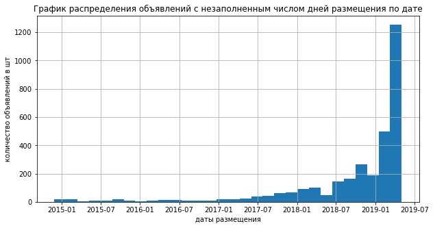

```python
data.loc[data['days_exposition'].isna(), 'first_day_exposition'].hist(bins=30, figsize=(10,5))
plt.title('График распределения объявлений с незаполненным числом дней размещения по дате')
plt.ylabel('количество объявлений в шт')
plt.xlabel('даты размещения')
plt.show()
```

Судя по гистограмме большая часть объявлений с пропусками в днях размещения приходится на конечный период выборки. Можно предположить, что на период формирования таблицы эти объявления были еще актуальны. Посмотрим как распределяются объявления о продаже по датам в целом по таблице.

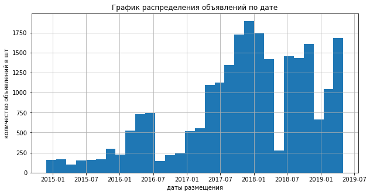

```python
data['first_day_exposition'].hist(bins=30, figsize=(10,5))
plt.title('График распределения объявлений по дате')
plt.ylabel('количество объявлений в шт')
plt.xlabel('даты размещения')
plt.show()
```

Похоже, что количество объявлений в конце периода близко к количеству объявлений в конце периода с незаполненным числом дней в продаже. Посчитаем общее количество объявлений в таблице за 2019 г. и количество объявлений за 2019 г. с пропусками в `days_exposition`

```python
data.loc[data['first_day_exposition'] > '2018-12-31', 'first_day_exposition'].count()
```

```
2879
```

```python
data.loc[(data['first_day_exposition'] > '2018-12-31') & (data['days_exposition'].isna()), 'first_day_exposition'].count()
```

```
1796
```

Количество объявлений с пропусками в колонке `days_exposition` в 2019 г. составляет 62% от общего числа объявлений. В то время как за период до 2019 г. доля таких объявлений составляет менее 6,7%. Можно сделать вывод что объявления с незаполненным количеством дней размещения на момент сбора данных для таблицы были еще актуальны и информацию о количестве дней продажи этих квартир мы получить не можем. Для указанных объявлений эти данные следует оставить незаполненными и , возможно, исключить из исследования такие объявления.

### Изменение типов данных.

```python
# Посмотрим информацию о таблице

data.info()
```

```
<class 'pandas.core.frame.DataFrame'>
RangeIndex: 23650 entries, 0 to 23649
Data columns (total 22 columns):
 #   Column                Non-Null Count  Dtype
---  ------                --------------  -----
 0   total_images          23650 non-null  int64
 1   last_price            23650 non-null  float64
 2   total_area            23650 non-null  float64
 3   first_day_exposition  23650 non-null  datetime64[ns]
 4   rooms                 23650 non-null  int64
 5   ceiling_height        23650 non-null  float64
 6   floors_total          23650 non-null  float64
 7   living_area           23650 non-null  float64
 8   floor                 23650 non-null  int64
 9   is_apartment          23650 non-null  bool
 10  studio                23650 non-null  bool
 11  open_plan             23650 non-null  bool
 12  kitchen_area          23434 non-null  float64
 13  balcony               23650 non-null  float64
 14  locality_name         23650 non-null  object
 15  airports_nearest      23650 non-null  float64
 16  cityCenters_nearest   23650 non-null  float64
 17  parks_around3000      23650 non-null  float64
 18  parks_nearest         8065 non-null   float64
 19  ponds_around3000      23650 non-null  float64
 20  ponds_nearest         9737 non-null   float64
 21  days_exposition       20470 non-null  float64
dtypes: bool(3), datetime64[ns](1), float64(14), int64(3), object(1)
memory usage: 3.5+ MB
```

Мы уже преобразовали столбец `first_day_exposition` в формат datetime и округлили данные в нем до дней, для удобства исследования, а также столбец `is_apartment` в булев тип, согласно описанию таблицы. Еще можно привести к целочисленному формату столбцы `floors_total`, `balcony`, `parks_around3000`, `ponds_around3000`, т.к. их значения не могут быть дробными. Для удобства работы преобразуем и значения`last_price` в целочисленные. Заменить формат в столбце `days_exposition` на целочисленный нельзя, т.к. в нем есть незаполненные значения, которые относятся к формату float.

```python
data['floors_total'] = data['floors_total'].astype('int')
data['balcony'] = data['balcony'].astype('int')
data['parks_around3000'] = data['parks_around3000'].astype('int')
data['ponds_around3000'] = data['ponds_around3000'].astype('int')
data['last_price'] = data['last_price'].astype('int')

#проверим результат
data.info()
```

```
<class 'pandas.core.frame.DataFrame'>
RangeIndex: 23650 entries, 0 to 23649
Data columns (total 22 columns):
 #   Column                Non-Null Count  Dtype
---  ------                --------------  -----
 0   total_images          23650 non-null  int64
 1   last_price            23650 non-null  int32
 2   total_area            23650 non-null  float64
 3   first_day_exposition  23650 non-null  datetime64[ns]
 4   rooms                 23650 non-null  int64
 5   ceiling_height        23650 non-null  float64
 6   floors_total          23650 non-null  int32
 7   living_area           23650 non-null  float64
 8   floor                 23650 non-null  int64
 9   is_apartment          23650 non-null  bool
 10  studio                23650 non-null  bool
 11  open_plan             23650 non-null  bool
 12  kitchen_area          23434 non-null  float64
 13  balcony               23650 non-null  int32
 14  locality_name         23650 non-null  object
 15  airports_nearest      23650 non-null  float64
 16  cityCenters_nearest   23650 non-null  float64
 17  parks_around3000      23650 non-null  int32
 18  parks_nearest         8065 non-null   float64
 19  ponds_around3000      23650 non-null  int32
 20  ponds_nearest         9737 non-null   float64
 21  days_exposition       20470 non-null  float64
dtypes: bool(3), datetime64[ns](1), float64(9), int32(5), int64(3), object(1)
memory usage: 3.0+ MB
```

## Расчёты и добавление результатов в таблицу

### Добавление столбца с ценой за 1 кв м

Добавим к таблице колонку цена за 1 кв м и проверим результат

```python
data['price_sq_m'] = data['last_price'] / data['total_area']

data.head()
```

|  | total_images | last_price | total_area | first_day_exposition | rooms | ceiling_height | floors_total | living_area | floor | is_apartment | ... | balcony | locality_name | airports_nearest | cityCenters_nearest | parks_around3000 | parks_nearest | ponds_around3000 | ponds_nearest | days_exposition | price_sq_m |
| --- | --- | --- | --- | --- | --- | --- | --- | --- | --- | --- | --- | --- | --- | --- | --- | --- | --- | --- | --- | --- | --- |
| 0 | 20 | 13000000 | 108.0 | 2019-03-07 | 3 | 2.70 | 16 | 51.000 | 8 | False | ... | 0 | Санкт-Петербург | 18863.0 | 16028.0 | 1 | 482.0 | 2 | 755.0 | NaN | 120370.370370 |
| 1 | 7 | 3350000 | 40.4 | 2018-12-04 | 1 | 2.63 | 11 | 18.600 | 1 | False | ... | 2 | Шушары | 12817.0 | 18603.0 | 0 | NaN | 0 | NaN | 81.0 | 82920.792079 |
| 2 | 10 | 5196000 | 56.0 | 2015-08-20 | 2 | 2.70 | 5 | 34.300 | 4 | False | ... | 0 | Санкт-Петербург | 21741.0 | 13933.0 | 1 | 90.0 | 2 | 574.0 | 558.0 | 92785.714286 |
| 3 | 0 | 64900000 | 159.0 | 2015-07-24 | 3 | 2.70 | 14 | 100.435 | 9 | False | ... | 0 | Санкт-Петербург | 28098.0 | 6800.0 | 2 | 84.0 | 3 | 234.0 | 424.0 | 408176.100629 |
| 4 | 2 | 10000000 | 100.0 | 2018-06-19 | 2 | 3.03 | 14 | 32.000 | 13 | False | ... | 0 | Санкт-Петербург | 31856.0 | 8098.0 | 2 | 112.0 | 1 | 48.0 | 121.0 | 100000.000000 |

5 rows × 23 columns

### Добавление столбцов с соотношением площадей - жилой к общей и кухни к общей.

Добавим колонки с соотношением площадей:

1. жилой и общей
2. кухни иобщей

И проверим результат

```python
data['ratio_living_total_area'] = data['living_area'] / data['total_area']

data['ratio_kitchen_total_area'] = data['kitchen_area'] / data['total_area']

data.head()
```

|  | total_images | last_price | total_area | first_day_exposition | rooms | ceiling_height | floors_total | living_area | floor | is_apartment | ... | airports_nearest | cityCenters_nearest | parks_around3000 | parks_nearest | ponds_around3000 | ponds_nearest | days_exposition | price_sq_m | ratio_living_total_area | ratio_kitchen_total_area |
| --- | --- | --- | --- | --- | --- | --- | --- | --- | --- | --- | --- | --- | --- | --- | --- | --- | --- | --- | --- | --- | --- |
| 0 | 20 | 13000000 | 108.0 | 2019-03-07 | 3 | 2.70 | 16 | 51.000 | 8 | False | ... | 18863.0 | 16028.0 | 1 | 482.0 | 2 | 755.0 | NaN | 120370.370370 | 0.472222 | 0.231481 |
| 1 | 7 | 3350000 | 40.4 | 2018-12-04 | 1 | 2.63 | 11 | 18.600 | 1 | False | ... | 12817.0 | 18603.0 | 0 | NaN | 0 | NaN | 81.0 | 82920.792079 | 0.460396 | 0.272277 |
| 2 | 10 | 5196000 | 56.0 | 2015-08-20 | 2 | 2.70 | 5 | 34.300 | 4 | False | ... | 21741.0 | 13933.0 | 1 | 90.0 | 2 | 574.0 | 558.0 | 92785.714286 | 0.612500 | 0.148214 |
| 3 | 0 | 64900000 | 159.0 | 2015-07-24 | 3 | 2.70 | 14 | 100.435 | 9 | False | ... | 28098.0 | 6800.0 | 2 | 84.0 | 3 | 234.0 | 424.0 | 408176.100629 | 0.631667 | 0.128571 |
| 4 | 2 | 10000000 | 100.0 | 2018-06-19 | 2 | 3.03 | 14 | 32.000 | 13 | False | ... | 31856.0 | 8098.0 | 2 | 112.0 | 1 | 48.0 | 121.0 | 100000.000000 | 0.320000 | 0.410000 |

5 rows × 25 columns

Посмотрим как заполнился столбец, там где площадь кухни не заполнена.

```python
data.loc[data['kitchen_area'].isna()].head()
```

|  | total_images | last_price | total_area | first_day_exposition | rooms | ceiling_height | floors_total | living_area | floor | is_apartment | ... | airports_nearest | cityCenters_nearest | parks_around3000 | parks_nearest | ponds_around3000 | ponds_nearest | days_exposition | price_sq_m | ratio_living_total_area | ratio_kitchen_total_area |
| --- | --- | --- | --- | --- | --- | --- | --- | --- | --- | --- | --- | --- | --- | --- | --- | --- | --- | --- | --- | --- | --- |
| 144 | 1 | 2450000 | 27.00 | 2017-03-30 | 1 | 2.70 | 24 | 15.500000 | 2 | False | ... | 51553.0 | 21888.0 | 0 | NaN | 2 | 133.0 | 181.0 | 90740.740741 | 0.574074 | NaN |
| 349 | 4 | 2320000 | 25.00 | 2017-09-27 | 1 | 2.75 | 14 | 17.000000 | 1 | False | ... | 26756.5 | 30371.0 | 0 | NaN | 0 | NaN | 45.0 | 92800.000000 | 0.680000 | NaN |
| 440 | 8 | 2480000 | 27.11 | 2018-03-12 | 1 | 2.70 | 17 | 24.750000 | 4 | False | ... | 38171.0 | 15015.0 | 0 | NaN | 2 | 982.0 | 64.0 | 91479.158982 | 0.912947 | NaN |
| 508 | 0 | 3375000 | 34.40 | 2017-03-28 | 1 | 2.64 | 26 | 24.300000 | 19 | False | ... | 53115.0 | 19292.0 | 0 | NaN | 1 | 593.0 | 430.0 | 98110.465116 | 0.706395 | NaN |
| 608 | 2 | 1850000 | 25.00 | 2019-02-20 | 1 | 2.63 | 10 | 12.121212 | 7 | False | ... | 17427.0 | 24212.0 | 0 | NaN | 0 | NaN | 29.0 | 74000.000000 | 0.484848 | NaN |

5 rows × 25 columns

Эти значения тоже остались незаполненными, что верно.

### Добавление столбцов с днем недели, месяцем и годом размещения объявления.

```python
data['weekday_exposition'] = data['first_day_exposition'].dt.weekday
data['month_exposition'] = data['first_day_exposition'].dt.month
data['year_exposition'] = data['first_day_exposition'].dt.year
data.head()
```

|  | total_images | last_price | total_area | first_day_exposition | rooms | ceiling_height | floors_total | living_area | floor | is_apartment | ... | parks_nearest | ponds_around3000 | ponds_nearest | days_exposition | price_sq_m | ratio_living_total_area | ratio_kitchen_total_area | weekday_exposition | month_exposition | year_exposition |
| --- | --- | --- | --- | --- | --- | --- | --- | --- | --- | --- | --- | --- | --- | --- | --- | --- | --- | --- | --- | --- | --- |
| 0 | 20 | 13000000 | 108.0 | 2019-03-07 | 3 | 2.70 | 16 | 51.000 | 8 | False | ... | 482.0 | 2 | 755.0 | NaN | 120370.370370 | 0.472222 | 0.231481 | 3 | 3 | 2019 |
| 1 | 7 | 3350000 | 40.4 | 2018-12-04 | 1 | 2.63 | 11 | 18.600 | 1 | False | ... | NaN | 0 | NaN | 81.0 | 82920.792079 | 0.460396 | 0.272277 | 1 | 12 | 2018 |
| 2 | 10 | 5196000 | 56.0 | 2015-08-20 | 2 | 2.70 | 5 | 34.300 | 4 | False | ... | 90.0 | 2 | 574.0 | 558.0 | 92785.714286 | 0.612500 | 0.148214 | 3 | 8 | 2015 |
| 3 | 0 | 64900000 | 159.0 | 2015-07-24 | 3 | 2.70 | 14 | 100.435 | 9 | False | ... | 84.0 | 3 | 234.0 | 424.0 | 408176.100629 | 0.631667 | 0.128571 | 4 | 7 | 2015 |
| 4 | 2 | 10000000 | 100.0 | 2018-06-19 | 2 | 3.03 | 14 | 32.000 | 13 | False | ... | 112.0 | 1 | 48.0 | 121.0 | 100000.000000 | 0.320000 | 0.410000 | 1 | 6 | 2018 |

5 rows × 28 columns

### Добавление столбца с категорией этажа - первый, последний или другой.

Напишем функцию для определения категории этажа (первый, последний или другой) и проверим ее

```python
def floor_category(row_floors):
    if row_floors['floor'] == row_floors['floors_total'] and row_floors['floors_total'] != 1:
        return 'последний'
    if row_floors['floor'] == 1:
        return 'первый'
    return 'другой'


floors = pd.DataFrame(data=[[1,5],[3,10], [1,1], [9,9]
                                  ],
                           columns = ['floor', 'floors_total'])
floors['category'] = floors.apply(floor_category, axis=1)
floors
```

|  | floor | floors_total | category |
| --- | --- | --- | --- |
| 0 | 1 | 5 | первый |
| 1 | 3 | 10 | другой |
| 2 | 1 | 1 | первый |
| 3 | 9 | 9 | последний |

Добавим столбец с категорией этажа к таблице.

```python
data['floor_category'] = data.apply(floor_category, axis=1)

data.head()
```

|  | total_images | last_price | total_area | first_day_exposition | rooms | ceiling_height | floors_total | living_area | floor | is_apartment | ... | ponds_around3000 | ponds_nearest | days_exposition | price_sq_m | ratio_living_total_area | ratio_kitchen_total_area | weekday_exposition | month_exposition | year_exposition | floor_category |
| --- | --- | --- | --- | --- | --- | --- | --- | --- | --- | --- | --- | --- | --- | --- | --- | --- | --- | --- | --- | --- | --- |
| 0 | 20 | 13000000 | 108.0 | 2019-03-07 | 3 | 2.70 | 16 | 51.000 | 8 | False | ... | 2 | 755.0 | NaN | 120370.370370 | 0.472222 | 0.231481 | 3 | 3 | 2019 | другой |
| 1 | 7 | 3350000 | 40.4 | 2018-12-04 | 1 | 2.63 | 11 | 18.600 | 1 | False | ... | 0 | NaN | 81.0 | 82920.792079 | 0.460396 | 0.272277 | 1 | 12 | 2018 | первый |
| 2 | 10 | 5196000 | 56.0 | 2015-08-20 | 2 | 2.70 | 5 | 34.300 | 4 | False | ... | 2 | 574.0 | 558.0 | 92785.714286 | 0.612500 | 0.148214 | 3 | 8 | 2015 | другой |
| 3 | 0 | 64900000 | 159.0 | 2015-07-24 | 3 | 2.70 | 14 | 100.435 | 9 | False | ... | 3 | 234.0 | 424.0 | 408176.100629 | 0.631667 | 0.128571 | 4 | 7 | 2015 | другой |
| 4 | 2 | 10000000 | 100.0 | 2018-06-19 | 2 | 3.03 | 14 | 32.000 | 13 | False | ... | 1 | 48.0 | 121.0 | 100000.000000 | 0.320000 | 0.410000 | 1 | 6 | 2018 | другой |

5 rows × 29 columns

### Результат добавления новых столбцов

Посмотрим информацию о таблице уже с новыми столбцами.

```python
data.info()
```

```
<class 'pandas.core.frame.DataFrame'>
RangeIndex: 23650 entries, 0 to 23649
Data columns (total 29 columns):
 #   Column                    Non-Null Count  Dtype
---  ------                    --------------  -----
 0   total_images              23650 non-null  int64
 1   last_price                23650 non-null  int32
 2   total_area                23650 non-null  float64
 3   first_day_exposition      23650 non-null  datetime64[ns]
 4   rooms                     23650 non-null  int64
 5   ceiling_height            23650 non-null  float64
 6   floors_total              23650 non-null  int32
 7   living_area               23650 non-null  float64
 8   floor                     23650 non-null  int64
 9   is_apartment              23650 non-null  bool
```

[output cut: 21 more lines]

Теперь в таблице 29 колонок. Все строки в добавленных столбцах заполнены, кроме столбца `ratio_kitchen_total_area`. Количество незаполненных строк в нем соответсмтвует количеству объявлений с квартирами-студиями и квартирами со свободной планировкой, где нет отдельной кухни и площадь кухни в таких объявлениях не заполнена.

## Исследовательский анализ данных

### Параметры продаваемых квартир.

#### Площадь квартир

Посмотрим на статистику общей площади, применив метод `describe()`

```python
data['total_area'].describe()
```

```
count    23650.000000
mean        60.329069
std         35.661808
min         12.000000
25%         40.000000
50%         52.000000
75%         69.700000
max        900.000000
Name: total_area, dtype: float64
```

Средний показатель заметно больше медианного, что говорит о наличии в распределении либо хвоста с высокими значениями, либо нескольких очень высоких значений. О наличии аномально высоких значений говорит и максимальный показатель площади, который в 17 раз больше медианы.

Построим диаграмму размаха для площади продаваемых квартир.

```
<function matplotlib.pyplot.show(close=None, block=None)>
```

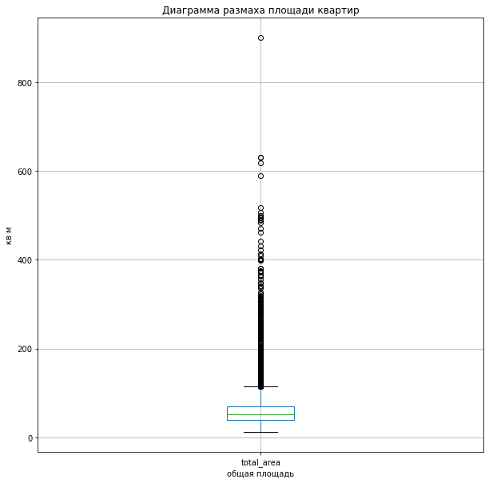

```python
data.boxplot('total_area', figsize=(10,10), grid=True )
plt.title('Диаграмма размаха площади квартир')
plt.ylabel('кв м')
plt.xlabel('общая площадь')
plt.show
```

По диаграмме видно, что разброс значений очень велик, за границами нормального распределения находятся площади уже примерно свыше 115 кв м. Чтобы построить читаемую гистограмму, ее границы лучше определить в пределах нормальных значений, исключая выбросы.

Посчитаем границы нормального распределения. Напишем функцию для их расчета.

```python
def normal_borders(df, column):
    left_border=df[column].quantile(0.25)-1.5*(df[column].quantile(0.75)-df[column].quantile(0.25))
    right_border=df[column].quantile(0.75)+1.5*(df[column].quantile(0.75)-df[column].quantile(0.25))
    if left_border < 0:
        left_border = 0
    return left_border, right_border
```

```python
normal_borders(data, 'total_area') # применим функцию к столбцу 'total_area'
```

```
(0, 114.25)
```

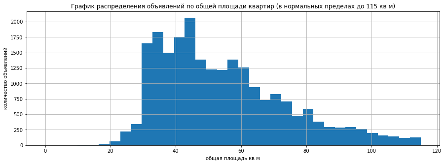

```python
data['total_area'].hist(range=(0, 115), bins=35, figsize=(15,5),)
plt.title('График распределения объявлений по общей площади квартир (в нормальных пределах до 115 кв м)')
plt.ylabel('количество объявлений')
plt.xlabel('общая площадь кв м')
```

#### Цена квартир

Посмотрим на статистику по цене квартир

```python
data['last_price'].describe()
```

```
count    2.365000e+04
mean     6.541127e+06
std      1.089640e+07
min      1.219000e+04
25%      3.400000e+06
50%      4.650000e+06
75%      6.799000e+06
max      7.630000e+08
Name: last_price, dtype: float64
```

Средний показатель в 1,4 раза выше медианы. Что говорит о наличии либо нескольких очень высоких значений, либо хвоста с высокими значениями за пределами нормальных. Максимальная цена в 164 раза больше медианы. Также очень велико стандартное отклонение (почти 11 млн), оно выше чем 3 квартиль. Построим диаграмму размаха для цены за квартиру, для того, чтобы она была читаемой ограничим значения оси Y значением в 40млн

```
(0.0, 40000000.0)
```

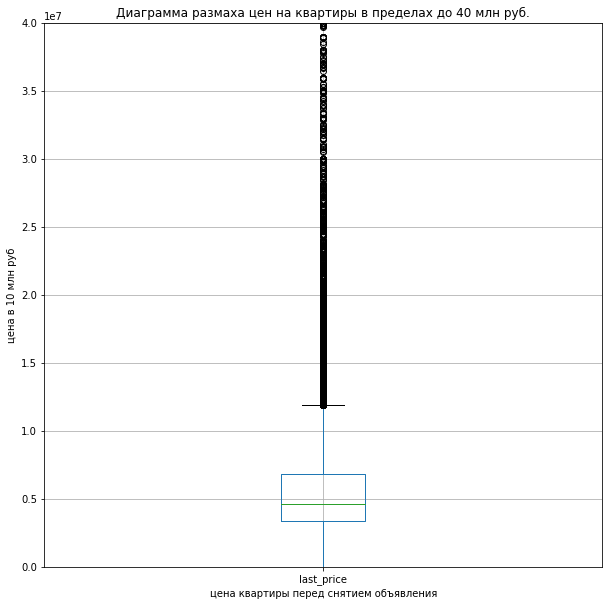

```python
data.boxplot('last_price', figsize=(10,10), grid=True )
plt.title('Диаграмма размаха цен на квартиры в пределах до 40 млн руб.')
plt.ylabel('цена в 10 млн руб')
plt.xlabel('цена квартиры перед снятием объявления')


plt.ylim(0 ,40000000)
```

Медиана стремится к нижней границе нормальных значений, значит в общем значений за пределами верхней границы нормальных значений все таки не так много. Граница нормальных значений от 0 до примерно 11 млн. Для того, чтобы построить читаемую гистограмму, посчитаем границы нормальных значений для цены.

```python
normal_borders(data, 'last_price')
```

```
(0, 11897500.0)
```

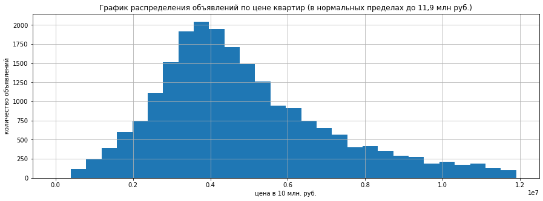

```python
data['last_price'].plot(kind='hist', range=(0, 11900000),bins=30, figsize=(15,5), grid=True,)
plt.title('График распределения объявлений по цене квартир (в нормальных пределах до 11,9 млн руб.)')
plt.ylabel('количество объявлений')
plt.xlabel('цена в 10 млн. руб.')
```

Рассмотрим показатель цены за 1 кв м

Посмотрим статистику.

```python
data['price_sq_m'].describe()
```

```
count    2.365000e+04
mean     9.943225e+04
std      5.033794e+04
min      1.118349e+02
25%      7.661497e+04
50%      9.500000e+04
75%      1.142742e+05
max      1.907500e+06
Name: price_sq_m, dtype: float64
```

Здесь среднее незначительно выше медианы, также стандартное отклонение меньше медианы и среднего почти в 2 раза, в отличии от таких же показателей цены за квартиру. Цена за квадратный метр менее подвержена выбросам, разброс значений здесь значительно меньше.

Построим диагармму размаха для цены за 1 кв м

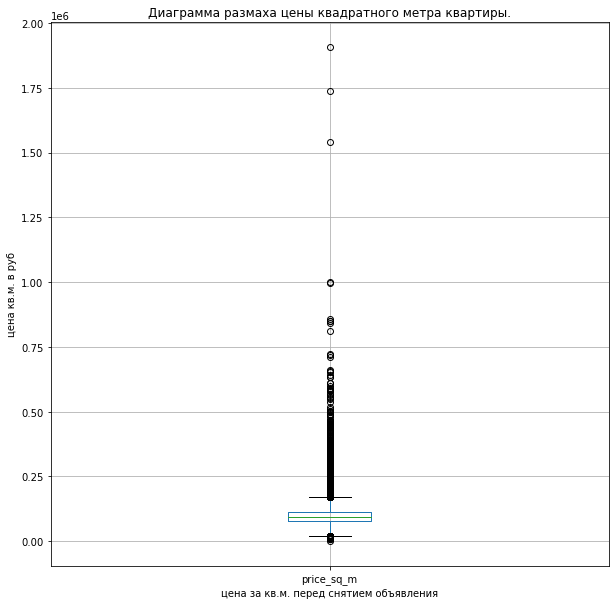

```python
data.boxplot('price_sq_m', figsize=(10,10), grid=True )
plt.title('Диаграмма размаха цены квадратного метра квартиры.')
plt.ylabel('цена кв.м. в руб')
plt.xlabel('цена за кв.м. перед снятием объявления')
```

На графике тоже видно, что цена за 1 кв м уже менее подвержен выбросам, медиану и межквартильный размах можно увидеть, не обрезая границы, хвост не такой длинный, свыше 750тыс находится лишь несколько отдельных значений.

Посчитаем границы нормальных значений и построим гистограмму в их пределлах.

```python
normal_borders(data, 'price_sq_m')
```

```
(20126.18202048963, 170762.94335716774)
```

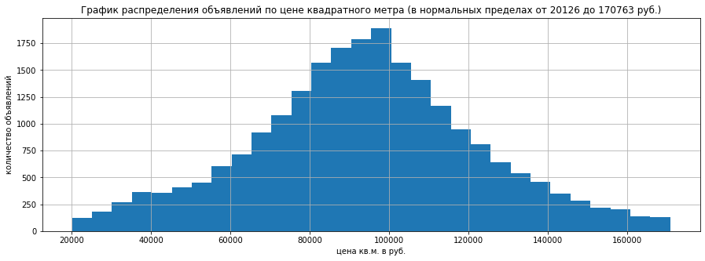

```python
data['price_sq_m'].plot(kind='hist', range=(20126, 170763),bins=30, figsize=(15,5), grid=True)
plt.title('График распределения объявлений по цене квадратного метра (в нормальных пределах от 20126 до 170763 руб.)')
plt.ylabel('количество объявлений')
plt.xlabel('цена кв.м. в руб.')
```

#### Число комнат

Посмотрим на статистику по комнатам.

```python
data['rooms'].describe()
```

```
count    23650.000000
mean         2.078901
std          1.068320
min          1.000000
25%          1.000000
50%          2.000000
75%          3.000000
max         19.000000
Name: rooms, dtype: float64
```

Среднее число комнат в продаваемых квартирах совпадает с медианным. Стандартное отклонение соответствует 1 комнате. Можно сказать, что этот показатель содержит небольшое количество выбросов. Построим диаграмму размаха для числа комнат.

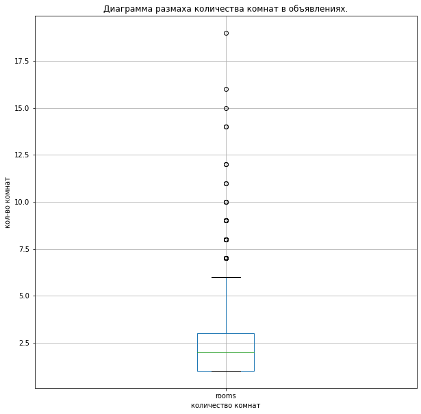

```python
data.boxplot('rooms', figsize=(10,10), grid=True )
plt.title('Диаграмма размаха количества комнат в объявлениях.')
plt.ylabel('кол-во комнат')
plt.xlabel('количество комнат')
```

На графике видно, что медиана равна 2 комнатам, и есть всего несколько значений, выходящих за пределы межквартильного размаха.

Посчитаем границы нормальных значений для построения гистограммы.

```python
normal_borders(data, 'rooms')
```

```
(0, 6.0)
```

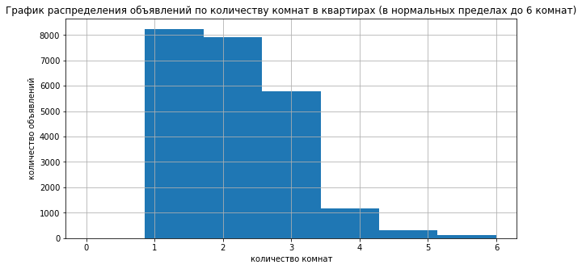

```python
data['rooms'].plot(kind='hist', range=(0,6),bins=7, figsize=(10,5), grid=True)
plt.title('График распределения объявлений по количеству комнат в квартирах (в нормальных пределах до 6 комнат)')
plt.ylabel('количество объявлений')
plt.xlabel('количество комнат')
```

Большая часть продаваемых квартир однокомнатные - более 8.2 тыс объявлений (почти 35%), чють меньше двухкомнатных квартир - около 7.9 тыс (33%) объявлений. Около 5.8 тыс объявлений с трехкомнатными квартирами (около 25%). Объявлений о продаже квартир с 4-мя комнатами и более - менее 2тыс, они составляют менее 8% выборки.

#### Высота потолков

Посмотрим на статистику высоты потолков, применив метод `describe()`

```python
data['ceiling_height'].describe()
```

```
count    23650.000000
mean         2.709063
std          0.681318
min          1.000000
25%          2.550000
50%          2.700000
75%          2.700000
max        100.000000
Name: ceiling_height, dtype: float64
```

Мы уже отмечали, что минимальный и максимальные показатели высоты потолков вызывают сомнения. Однако, не смотря на большой разброс данных средний показатель совпадает с медианным, а также со значением на границе 75% показателей в выборке. Все таки в целом высоты потолков мало отличаются между собой, даже наличие выбросов не изменяет средний показатель.

Построим диаграмму размаха для высоты потолков. Нам известно, что максимальное значение этого показателя 100 м, это явно значительно за пределами нормальных значений. Чтобы график был читаемый, определим границу оси Y 5 метрами

```
(1.0, 5.0)
```

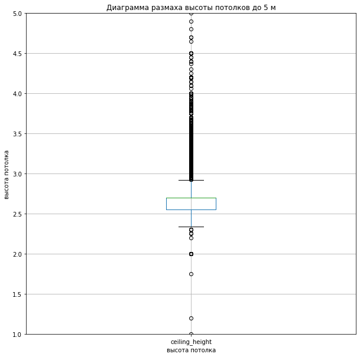

```python
data.boxplot('ceiling_height', figsize=(10,10), grid=True )
plt.title('Диаграмма размаха высоты потолков до 5 м')
plt.ylabel('высота потолка')
plt.xlabel('высота потолка')

plt.ylim(1 ,5)
```

На графике видно, что граница нормальных значений примерно от 2,3 м до 2,9 м. Медиана на графике не отличается по значению от 3 квартиля. Начиная примерно с 2,8 м значение высоты потолков сильно не меняется и поэтому граница значений у 75% выборки не отличается от границы значений у 50% выборки.

Посчитаем границы нормальных значений для высоты потолков.

```python
normal_borders(data, 'ceiling_height')
```

```
(2.3249999999999993, 2.9250000000000007)
```

Пределы нормальных значений 2.3 м - 2.93 м. Построим график по этим значениям.

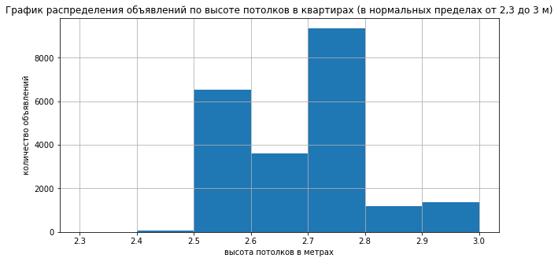

```python
data['ceiling_height'].plot(kind='hist', range=(2.3 , 3),bins=7, figsize=(10,5), grid=True)
plt.title('График распределения объявлений по высоте потолков в квартирах (в нормальных пределах от 2,3 до 3 м)')
plt.ylabel('количество объявлений')
plt.xlabel('высота потолков в метрах')
```

Большая часть квартир в таблице имеет высоту потолков около 2,7-2,8 м. (примерно 9,5 тыс объявлений - 40%). Потолки 2,5-2,6 составляют примерно 6,5 тыс объявлении (27%). Потолки 2,8-3 м встречаются реже (их доля примерно 10%)

#### Время продажи квартир.

Мы уже обратили внимание, что минимальное время продажи квартиры в таблице 1 день, максимальное 1580 дней. Здесь самый большой разброс данных. Кроме того в столбце остались незаполненные значения, потому что большая часть пропусков относится к квартирам выставленным на продажу непосредственно перед получением таблицы, и на момент ее формирования эти квартиры еще не проданы. Таких объявлений 3180 (13% от всей выборки). Применим метод describe() к столбцу.

```python
data['days_exposition'].describe()
```

```
count    20470.000000
mean       180.753200
std        219.777916
min          1.000000
25%         45.000000
50%         95.000000
75%        231.000000
max       1580.000000
Name: days_exposition, dtype: float64
```

Среднее почти в 2 раза больше медианы, значит в распределении есть длинный хвост с высокими значениями или несколько очень больших значений, это влияет на величину среднего показателя.

Построим диаграмму размаха для столбца `days_exposition`

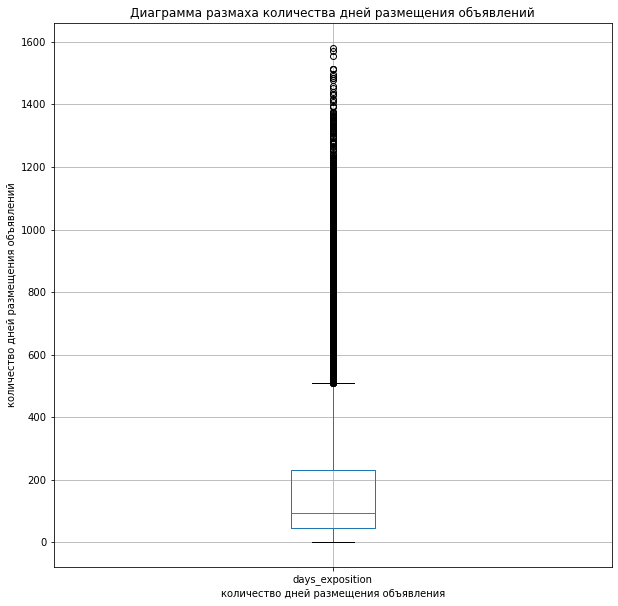

```python
data.boxplot('days_exposition', figsize=(10,10), grid=True )
plt.title('Диаграмма размаха количества дней размещения объявлений')
plt.ylabel('количество дней размещения объявлений')
plt.xlabel('количество дней размещения объявления')
```

На графике видно, что интервал нормальных значений от 0 до приблизительно 500 дней. Дальше идут выбросы. Эти значения не так часты, поскольку медиана смещена к нижней границе нормальных значений.

Посчитаем интервал нормальных значений

```python
normal_borders(data, 'days_exposition') # применим функцию к столбцу 'days_exposition'
```

```
(0, 510.0)
```

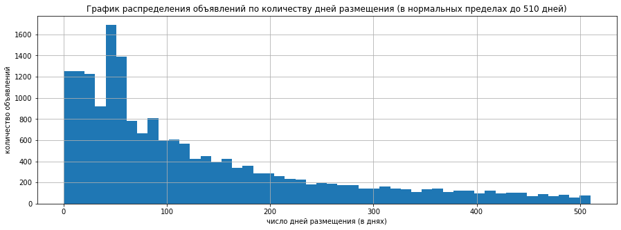

```python
data['days_exposition'].plot(kind='hist', range=(0 , 510),bins=50, figsize=(15,5), grid=True)
plt.title('График распределения объявлений по количеству дней размещения (в нормальных пределах до 510 дней)')
plt.ylabel('количество объявлений')
plt.xlabel('число дней размещения (в днях)')
```

В целом с увеличением срока продажи квартиры количество объявлений уменьшается.В первые 30 дней продается окло 3,6 тыс кв (15% объявлений). Большая часть квартир продается в срок до 95 дней. Однако в периоде от 0 до 95 дней есть несколько пиков 0-30 дней, 40-50дней и 80-90 дней. Построим отдельную гиксограмму для этого периода.

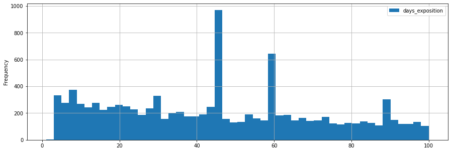

```python
data['days_exposition'].plot(kind='hist', range=(1 , 100),bins=50, figsize=(15,5), grid=True, legend=True, )
```

В цело можно сказать, что обычно продажа квартиры занимает до 95 дней (на этот период приходится половина объявлений). Быстрой можно считать продажу в период до 45 дней (25 процентов объявлений завершены в этот период) и долгой можно назвать продажу квартиры свыше 232 дней (75% объявлений в этот период уже завершены).

#### Расстояние до центра города.

Посмотрим на распределение значений в столбце с расстоянием до центра города. Построим диаграмму размаха, и статистику, применив метод describe().

```python
data['cityCenters_nearest'].describe()
```

```
count    23650.000000
mean     17713.061226
std       9995.178304
min        181.000000
25%      10939.000000
50%      14957.000000
75%      30371.000000
max      65968.000000
Name: cityCenters_nearest, dtype: float64
```

После заполнения пропусков медиана расстояния до центра увеличилась. Это связано с большим числом пропусков в областных населенных пунктах, где расстояние до центра больше, чем в Санкт-петербурге.

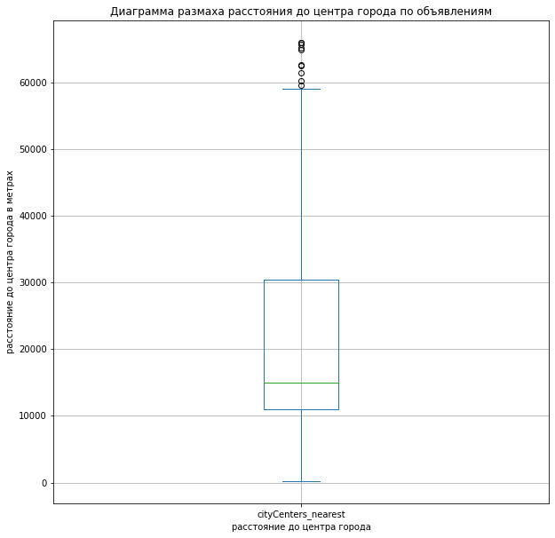

```python
data['cityCenters_nearest'].plot.box(grid=True, figsize=(10,10))
plt.title('Диаграмма размаха расстояния до центра города по объявлениям')
plt.ylabel('расстояние до центра города в метрах')
plt.xlabel('расстояние до центра города')
```

Значений, выходящих за пределы нормальных очень мало. Посчитаем границы нормальных значений.

```python
print(normal_borders(data,'cityCenters_nearest'))
```

```
(0, 59519.0)
```

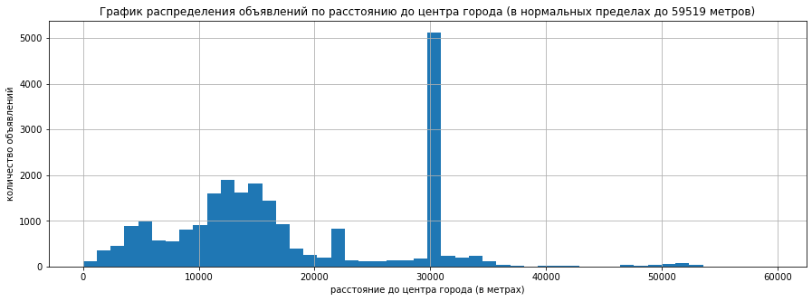

```python
data['cityCenters_nearest'].plot(kind='hist', range=(0 , 59519),bins=50, figsize=(15,5), grid=True)
plt.title('График распределения объявлений по расстоянию до центра города (в нормальных пределах до 59519 метров)')
plt.ylabel('количество объявлений')
plt.xlabel('расстояние до центра города (в метрах)')
```

График имеет несколько пиков. Основная часть квартир в продаже находятся на расстоянии до 18 км от центра. Затем примерно на 21-22 км небольшой пик - около 800 объявлений (видимо там находится крупный населенный пункт). Самому большому количеству объявлении соответствует расстояние 30 км - их основная часть - это объявления с пропусками в населенных пунктах, которые мы заполнили медианой (таких обявлений было 4830).Квартир на расстоянии свыше 35 км от центра очень мало, возможно, если бы не большое количество пропусков, картина была бы иной.

Уменьшим пределы построения гистограммы до 25тыс м, чтобы рассмоттреть основную часть объявлений

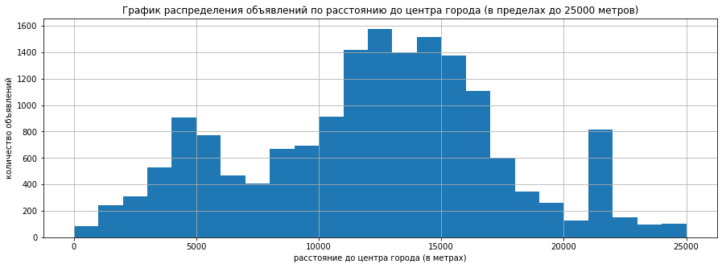

```python
data['cityCenters_nearest'].plot(kind='hist', range=(0 , 25000),bins=25, figsize=(15,5), grid=True)
plt.title('График распределения объявлений по расстоянию до центра города (в пределах до 25000 метров)')
plt.ylabel('количество объявлений')
plt.xlabel('расстояние до центра города (в метрах)')
```

### Удаление данных с редкими и выбивающимися значениями.

Для исследования необходимы данные о цене продажи, общей площади, количества, комнат, количества этажей в доме, этаж квартиры, расстояние до центра, количество дней размещения. Данные по паркам и прудам в исследоввании не учавствуют, поэтому аномальные значения и выбросы в этих колонках трогать не будем. Данныее по этажам мы категоризировали по признакам первый, последний, другой, и будем использовать в исследовании эти категории, поэтому выброс и аномалии в столбцах `floor` и `floors_total` нам не помешают.

Мы уже получили пределы нормальных распределений для столбцов с данными о плщщади квартиры, цене квартиры, количестве комнат, высоте потолков, расстоянии до центра, числа дней размещения.

Еще раз выведем их на экран. И, затем, отфильтруем таблицу, оставив в ней только строки с показателями в пределах нормальных распределений по этим значениям.

```python
print('Границы нормальных значений для столбца', 'total_area',normal_borders(data,'total_area'))
print('Границы нормальных значений для столбца', 'price_sq_m',normal_borders(data,'price_sq_m'))
print('Границы нормальных значений для столбца', 'rooms',normal_borders(data,'rooms'))
print('Границы нормальных значений для столбца', 'ceiling_height',normal_borders(data,'ceiling_height'))
print('Границы нормальных значений для столбца', 'days_exposition',normal_borders(data,'days_exposition'))
print('Границы нормальных значений для столбца', 'cityCenters_nearest',normal_borders(data,'cityCenters_nearest'))
```

```
Границы нормальных значений для столбца total_area (0, 114.25)
Границы нормальных значений для столбца price_sq_m (20126.18202048963, 170762.94335716774)
Границы нормальных значений для столбца rooms (0, 6.0)
Границы нормальных значений для столбца ceiling_height (2.3249999999999993, 2.9250000000000007)
Границы нормальных значений для столбца days_exposition (0, 510.0)
Границы нормальных значений для столбца cityCenters_nearest (0, 59519.0)
```

Сформируем таблицу со срезом данных в границах нормального распределения

```python
data_new = (
    data.query(
        '(total_area <= 114.25) and (20126 <= price_sq_m <= 170763) and (rooms <= 6) and (2.325 <= ceiling_height <= 2.925) and (days_exposition <= 510) and (cityCenters_nearest <=59519)')
)
data_new.info()
data_new.head()
```

```
<class 'pandas.core.frame.DataFrame'>
Int64Index: 16223 entries, 1 to 23646
Data columns (total 29 columns):
 #   Column                    Non-Null Count  Dtype
---  ------                    --------------  -----
 0   total_images              16223 non-null  int64
 1   last_price                16223 non-null  int32
 2   total_area                16223 non-null  float64
 3   first_day_exposition      16223 non-null  datetime64[ns]
 4   rooms                     16223 non-null  int64
 5   ceiling_height            16223 non-null  float64
 6   floors_total              16223 non-null  int32
 7   living_area               16223 non-null  float64
 8   floor                     16223 non-null  int64
 9   is_apartment              16223 non-null  bool
```

[output cut: 21 more lines]

|  | total_images | last_price | total_area | first_day_exposition | rooms | ceiling_height | floors_total | living_area | floor | is_apartment | ... | ponds_around3000 | ponds_nearest | days_exposition | price_sq_m | ratio_living_total_area | ratio_kitchen_total_area | weekday_exposition | month_exposition | year_exposition | floor_category |
| --- | --- | --- | --- | --- | --- | --- | --- | --- | --- | --- | --- | --- | --- | --- | --- | --- | --- | --- | --- | --- | --- |
| 1 | 7 | 3350000 | 40.40 | 2018-12-04 | 1 | 2.63 | 11 | 18.60 | 1 | False | ... | 0 | NaN | 81.0 | 82920.792079 | 0.460396 | 0.272277 | 1 | 12 | 2018 | первый |
| 5 | 10 | 2890000 | 30.40 | 2018-09-10 | 1 | 2.65 | 12 | 14.40 | 5 | False | ... | 0 | NaN | 55.0 | 95065.789474 | 0.473684 | 0.299342 | 0 | 9 | 2018 | другой |
| 6 | 6 | 3700000 | 37.30 | 2017-11-02 | 1 | 2.64 | 26 | 10.60 | 6 | False | ... | 0 | NaN | 155.0 | 99195.710456 | 0.284182 | 0.386059 | 3 | 11 | 2017 | другой |
| 8 | 20 | 2900000 | 33.16 | 2018-05-23 | 1 | 2.70 | 27 | 15.43 | 26 | False | ... | 2 | 133.0 | 189.0 | 87454.764777 | 0.465320 | 0.265682 | 2 | 5 | 2018 | другой |
| 9 | 18 | 5400000 | 61.00 | 2017-02-26 | 3 | 2.50 | 9 | 43.60 | 7 | False | ... | 0 | NaN | 289.0 | 88524.590164 | 0.714754 | 0.106557 | 6 | 2 | 2017 | другой |

5 rows × 29 columns

Посмотрим на статистику в исходной таблице и таблице собранной в пределах нормальных значений

```python
data.describe()
```

|  | total_images | last_price | total_area | rooms | ceiling_height | floors_total | living_area | floor | kitchen_area | balcony | ... | parks_nearest | ponds_around3000 | ponds_nearest | days_exposition | price_sq_m | ratio_living_total_area | ratio_kitchen_total_area | weekday_exposition | month_exposition | year_exposition |
| --- | --- | --- | --- | --- | --- | --- | --- | --- | --- | --- | --- | --- | --- | --- | --- | --- | --- | --- | --- | --- | --- |
| count | 23650.000000 | 2.365000e+04 | 23650.000000 | 23650.000000 | 23650.000000 | 23650.000000 | 23650.000000 | 23650.000000 | 23434.000000 | 23650.000000 | ... | 8065.000000 | 23650.000000 | 9737.000000 | 20470.000000 | 2.365000e+04 | 23650.000000 | 23434.000000 | 23650.000000 | 23650.000000 | 23650.000000 |
| mean | 9.862326 | 6.541127e+06 | 60.329069 | 2.078901 | 2.709063 | 10.684059 | 34.677839 | 5.893277 | 10.488303 | 0.591712 | ... | 490.806200 | 0.642833 | 494.693951 | 180.753200 | 9.943225e+04 | 0.564846 | 0.187142 | 2.568710 | 6.401564 | 2017.370021 |
| std | 5.682278 | 1.089640e+07 | 35.661808 | 1.068320 | 0.681318 | 6.597081 | 22.816130 | 4.883317 | 5.802010 | 0.959662 | ... | 342.540229 | 0.904553 | 283.621241 | 219.777916 | 5.033794e+04 | 0.102687 | 0.071490 | 1.788808 | 3.491418 | 1.037806 |
| min | 0.000000 | 1.219000e+04 | 12.000000 | 1.000000 | 1.000000 | 1.000000 | 2.000000 | 1.000000 | 1.300000 | 0.000000 | ... | 1.000000 | 0.000000 | 13.000000 | 1.000000 | 1.118349e+02 | 0.021583 | 0.025381 | 0.000000 | 1.000000 | 2014.000000 |
| 25% | 6.000000 | 3.400000e+06 | 40.000000 | 1.000000 | 2.550000 | 5.000000 | 18.700000 | 2.000000 | 7.100000 | 0.000000 | ... | 288.000000 | 0.000000 | 247.000000 | 45.000000 | 7.661497e+04 | 0.491178 | 0.133333 | 1.000000 | 3.000000 | 2017.000000 |
| 50% | 9.000000 | 4.650000e+06 | 52.000000 | 2.000000 | 2.700000 | 9.000000 | 30.000000 | 4.000000 | 9.020134 | 0.000000 | ... | 454.000000 | 0.000000 | 477.000000 | 95.000000 | 9.500000e+04 | 0.571429 | 0.170455 | 3.000000 | 6.000000 | 2017.000000 |
| 75% | 14.000000 | 6.799000e+06 | 69.700000 | 3.000000 | 2.700000 | 16.000000 | 42.318750 | 8.000000 | 11.800000 | 1.000000 | ... | 612.000000 | 1.000000 | 709.000000 | 231.000000 | 1.142742e+05 | 0.633333 | 0.236111 | 4.000000 | 10.000000 | 2018.000000 |
| max | 50.000000 | 7.630000e+08 | 900.000000 | 19.000000 | 100.000000 | 60.000000 | 430.133948 | 33.000000 | 122.444606 | 5.000000 | ... | 3190.000000 | 3.000000 | 1344.000000 | 1580.000000 | 1.907500e+06 | 1.000000 | 0.787879 | 6.000000 | 12.000000 | 2019.000000 |

8 rows × 23 columns

```python
data_new.describe()
```

|  | total_images | last_price | total_area | rooms | ceiling_height | floors_total | living_area | floor | kitchen_area | balcony | ... | parks_nearest | ponds_around3000 | ponds_nearest | days_exposition | price_sq_m | ratio_living_total_area | ratio_kitchen_total_area | weekday_exposition | month_exposition | year_exposition |
| --- | --- | --- | --- | --- | --- | --- | --- | --- | --- | --- | --- | --- | --- | --- | --- | --- | --- | --- | --- | --- | --- |
| count | 16223.000000 | 1.622300e+04 | 16223.000000 | 16223.000000 | 16223.000000 | 16223.000000 | 16223.000000 | 16223.000000 | 16042.000000 | 16223.000000 | ... | 4723.000000 | 16223.000000 | 6186.000000 | 16223.000000 | 16223.000000 | 16223.000000 | 16042.000000 | 16223.000000 | 16223.000000 | 16223.000000 |
| mean | 9.540775 | 4.713539e+06 | 51.592747 | 1.873821 | 2.639021 | 11.447451 | 29.323803 | 6.242372 | 9.453424 | 0.618381 | ... | 498.024772 | 0.559576 | 508.431135 | 123.688898 | 91502.905608 | 0.560016 | 0.192288 | 2.595697 | 6.610861 | 2017.360907 |
| std | 5.542935 | 2.261360e+06 | 17.678574 | 0.856873 | 0.095740 | 6.733459 | 12.397979 | 5.068772 | 3.631938 | 0.948443 | ... | 334.254107 | 0.824293 | 285.863558 | 118.554084 | 26847.014196 | 0.100350 | 0.068299 | 1.789695 | 3.487197 | 0.843356 |
| min | 0.000000 | 6.300000e+05 | 13.000000 | 1.000000 | 2.340000 | 1.000000 | 2.000000 | 1.000000 | 2.000000 | 0.000000 | ... | 1.000000 | 0.000000 | 13.000000 | 1.000000 | 20192.307692 | 0.069588 | 0.043524 | 0.000000 | 1.000000 | 2015.000000 |
| 25% | 6.000000 | 3.280000e+06 | 38.000000 | 1.000000 | 2.550000 | 5.000000 | 18.000000 | 3.000000 | 7.000000 | 0.000000 | ... | 300.000000 | 0.000000 | 263.000000 | 39.000000 | 75032.693150 | 0.485162 | 0.139535 | 1.000000 | 3.000000 | 2017.000000 |
| 50% | 9.000000 | 4.213395e+06 | 47.000000 | 2.000000 | 2.700000 | 9.000000 | 28.150000 | 5.000000 | 8.921283 | 0.000000 | ... | 462.000000 | 0.000000 | 495.000000 | 79.000000 | 92088.404869 | 0.564627 | 0.178571 | 3.000000 | 7.000000 | 2017.000000 |
| 75% | 13.000000 | 5.600000e+06 | 61.800000 | 2.000000 | 2.700000 | 16.000000 | 37.550000 | 9.000000 | 11.000000 | 1.000000 | ... | 622.000000 | 1.000000 | 725.750000 | 174.000000 | 107866.594422 | 0.631667 | 0.243902 | 4.000000 | 10.000000 | 2018.000000 |
| max | 50.000000 | 1.870000e+07 | 114.200000 | 6.000000 | 2.920000 | 60.000000 | 88.000000 | 33.000000 | 55.700000 | 5.000000 | ... | 3190.000000 | 3.000000 | 1344.000000 | 510.000000 | 170731.707317 | 1.000000 | 0.787879 | 6.000000 | 12.000000 | 2019.000000 |

8 rows × 23 columns

Сравним статистику в таблицах до удаления редких и выбивающихся значений и после.

```python
data_contrast = (data_new.describe()/ data.describe() * 100)-100
data_contrast
```

|  | total_images | last_price | total_area | rooms | ceiling_height | floors_total | living_area | floor | kitchen_area | balcony | ... | parks_nearest | ponds_around3000 | ponds_nearest | days_exposition | price_sq_m | ratio_living_total_area | ratio_kitchen_total_area | weekday_exposition | month_exposition | year_exposition |
| --- | --- | --- | --- | --- | --- | --- | --- | --- | --- | --- | --- | --- | --- | --- | --- | --- | --- | --- | --- | --- | --- |
| count | -31.403805 | -31.403805 | -31.403805 | -31.403805 | -31.403805 | -31.403805 | -31.403805 | -31.403805 | -31.543911 | -31.403805 | ... | -41.438314 | -31.403805 | -36.469138 | -20.747435 | -31.403805 | -31.403805 | -31.543911 | -31.403805 | -31.403805 | -31.403805 |
| mean | -3.260389 | -27.939961 | -14.481116 | -9.864806 | -2.585480 | 7.145149 | -15.439359 | 5.923614 | -9.866988 | 4.507060 | ... | 1.470758 | -12.951587 | 2.776906 | -31.570286 | -7.974618 | -0.855036 | 2.750150 | 1.050609 | 3.269461 | -0.000452 |
| std | -2.452249 | -79.246718 | -50.427152 | -19.792422 | -85.947826 | 2.067259 | -45.661344 | 3.797734 | -37.402061 | -1.169082 | ... | -2.419022 | -8.872985 | 0.790603 | -46.057326 | -46.666438 | -2.275977 | -4.463448 | 0.049587 | -0.120894 | -18.736633 |
| min | NaN | 5068.170632 | 8.333333 | 0.000000 | 134.000000 | 0.000000 | 0.000000 | 0.000000 | 53.846154 | NaN | ... | 0.000000 | NaN | 0.000000 | 0.000000 | 17955.467912 | 222.422680 | 71.484940 | NaN | 0.000000 | 0.049652 |
| 25% | 0.000000 | -3.529412 | -5.000000 | 0.000000 | 0.000000 | 0.000000 | -3.743316 | 50.000000 | -1.408451 | NaN | ... | 4.166667 | NaN | 6.477733 | -13.333333 | -2.065229 | -1.224904 | 4.651163 | 0.000000 | 0.000000 | 0.000000 |
| 50% | 0.000000 | -9.389355 | -9.615385 | 0.000000 | 0.000000 | 0.000000 | -6.166667 | 25.000000 | -1.095898 | NaN | ... | 1.762115 | NaN | 3.773585 | -16.842105 | -3.064837 | -1.190309 | 4.761905 | 0.000000 | 16.666667 | 0.000000 |
| 75% | -7.142857 | -17.634946 | -11.334290 | -33.333333 | 0.000000 | 0.000000 | -11.268646 | 12.500000 | -6.779661 | 0.000000 | ... | 1.633987 | 0.000000 | 2.362482 | -24.675325 | -5.607185 | -0.263158 | 3.299857 | 0.000000 | 0.000000 | 0.000000 |
| max | 0.000000 | -97.549148 | -87.311111 | -68.421053 | -97.080000 | 0.000000 | -79.541257 | 0.000000 | -54.510042 | 0.000000 | ... | 0.000000 | 0.000000 | 0.000000 | -67.721519 | -91.049452 | 0.000000 | 0.000000 | 0.000000 | 0.000000 | 0.000000 |

8 rows × 23 columns

После совместного удаления редких и выбивающихся значений из таблицы, там осталось 16223 строки из 23650 - удалили 31% строк, в том числе строки с незаполненным количеством дней размещения. Значительно изменились средние показатели (они уменьшились и стали ближе к медиане). У многих колонок уменьшились и сами медианы. Сильнее всего изменились показатели в колонке `days_exposition`, т.к. там изначально был самый большой разброс данных. Медиана по числу дней размещения уменьшилась с 95 дней до 79 (на 16%). В результате удаления аномалий минимальный показатель по цене вырос почти в 51 раз, а по цене 1 кв. м. почти в 180 раз. При это медиана цены продажи уменьшилась на 9,4%, а медиана цены за 1 кв м всего на 3,1 %, что говорит о том, что статистика по цене за 1 кв м менее подвержена влиянию выбросов и аномалий.

Медиана по общей площади уменьшилась почти на 10%, а по жилой на 6%. Возможно это говорит, о том, что большая часть удаленных аномальных квартир имели отличающиеся характеристики с большей долей нежилой площади. Тоже самое можно сказать про этажность. Если общая медиана по этажности зданий не изменилась, то медиана по этажу продаваемой квартиры увеличилась на 1 этаж. Можно сделать вывод, что среди удаленных объявлений преобладают здания нестандартной постройки с низкой этажностью и большой площадью, но их не много.

По дате размещения объявлений изменился только месяц большинства объявлений с июня 2017 он сдвинулся к июлю 2017 г. Возможно это произошло в результате удаления аномальных (слишком долго продающихся) и незаполненных значений столбца `days_exposition`.

### Влияние отдельных факторов на цену продажи квартиры.

#### Зависимость цены от площади квартиры, числа комнат и удаленности от центра.

Построим для показателей цены, площади, числа комнат и удаленности от центра матрицу диаграмм рассеивания

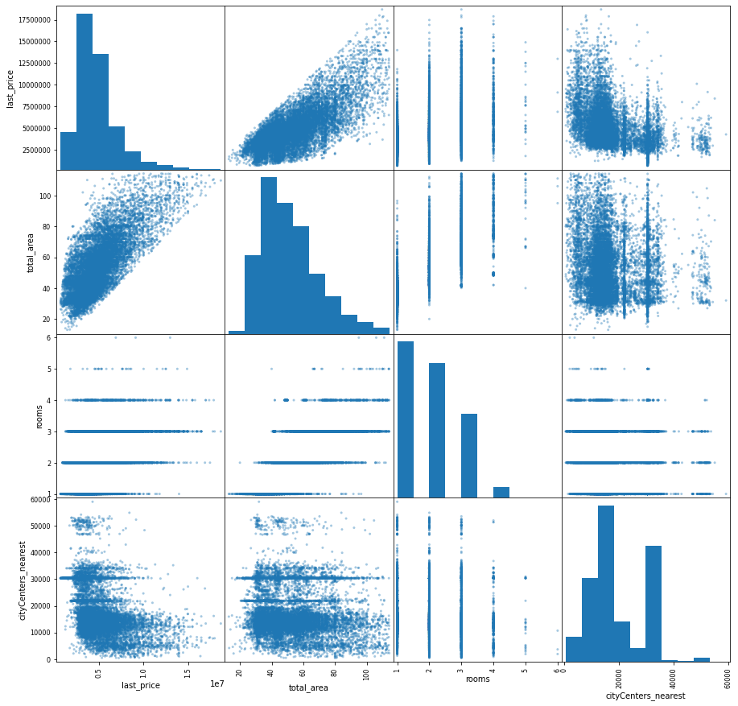

```python
pd.plotting.scatter_matrix(data_new[['last_price', 'total_area', 'rooms', 'cityCenters_nearest']] , alpha=0.4, figsize=(15, 15),);
```

На графике видно что цена за квариру на прямую зависит от площади и с увеличением площади цена растет. Также заметен довольно таки большой разброс цен для квартир с одинаковой площадью, и этот разброс увеличивается с увеличением площади квартиры. Цены на квартиры площадью до 30 кв м в основном находятся в диапазоне от 2 до 3 млн, то квартиры площадью около 40 кв м уже в диапазоне от 2 до 6 млн. Эту же зависимость можно увидеть на графике корреляции цены и количества комнат.Видно, что минимальная цена однокомнатной квартиры чуть меньше чем у 2-х комнатных и 3-х комнатных. Но в целом В диапазоне от 2,5 до до 8 млн. достаточно много квартир с разным количеством комнат. Дороже 8млн однокомнатных квартир уже практически нет. Также заметно уменьшается количество двухкомнатных квартир. Наибольшее число квартир дороже 8 млн среди 3-х комнатных. 4-х и 5-ти комнатных квартир гораздо меньше чем 3-х комнатных. Цена 5-ти комнатных квартир разбросана в пределах от 2,5 до 14 млн. Основная часть 4-х комнатных в пределах от 2,5 до 10 млн, также есть существенная группа 4-х комнатных кварир с ценой около 13 млн.

Что касается зависимости цены от удаленности от центра, на графике видно, что квартиры с наименьшим расстоянием от центра сосредоточеы в ценовом диапазоне от 5 до 15 млн руб., и таких квартир не так много. В целом ближе к центру увеличивается разброс цен и дорогих квартир становиться больше, но минимальная цена остается примерно на одном уровне, за исключением небольшого количества отдельных значений. Кроме того заметно большое количество квартир с разной ценой на расстоянии около 30 км от центра. Это последствия заполнения пропущенных значений медианой по областным населенным пунктам. Также есть большая сгруппированность объявлений на расстоянии примерно 21 тыс м, 32 тыс м, 35 тыс м. Наверное, на этих расстояниях расположены крупные населенные пункты.

Для того, чтобы снизить зависимость цены от площади, по сравнению с другими факторами, построим такую же матрицу диагармм рассеивания, применив показатель цена за 1 кв м

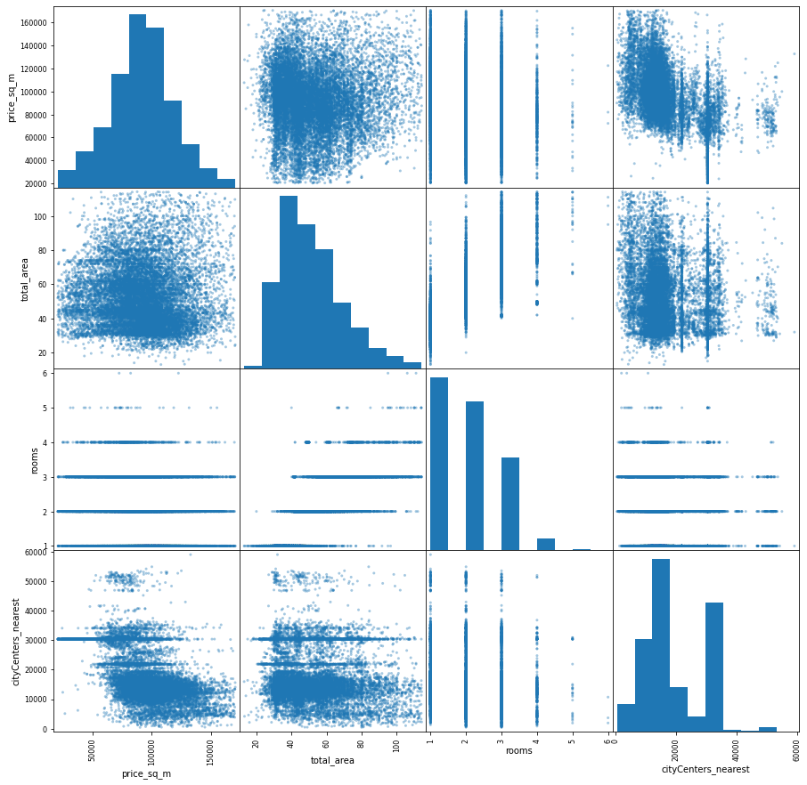

```python
pd.plotting.scatter_matrix(data_new[['price_sq_m', 'total_area', 'rooms', 'cityCenters_nearest']] , alpha=0.4, figsize=(15, 15),);
```

На этом графике уже явно прослеживается зависимость между ценой 1 кв м и расположением относительно центра. Видно, что наиболее дорогие по цене за 1 кв м квартиры сосредоточены на расстоянии менее 20 км от центра. С увеличением расстояния от центра дорогих квартир становится меньше. На этом графике еще более заметно аномально большое количество квартир на расстоянии 30 км от центра с большим диапазоном цен.

Зависимость от площади цены за 1 кв м гораздо менее явная . На графике видно, что большинство продаваемых квартир по площади от 30 до 40 кв м находятся в ценовом диапазоне примерно от 60 тыс до 130 тыс руб за кв м, а у квартир площадью 50-60 кв м от 70 тыс до 110 тыс руб за кв м. Далее, же с площади уже выше 80 кв м значения цен за кв м разбросаны и закономерности отследить сложно. Возможно это связано с небольшим количеством таких квартир в выборке.

Зависимость цены 1 кв м от количества комнат на этом графике также незаметна.Цена за 1 кв м 1,2,3-х комнатных квартир распределена по всему диапазону. Только у 4-х комнатных квартир видно что основная их часть не дороже 120 тыс руб за кв м. 5-ти комнатных квартир довольно таки мало, видно что большинство продаваемых 5-ти комнатных квартир в диапазоне примерно от 60 тыс до 90 тыс руб за кв м.

Посчитаем коэффициенты корреляции цены за 1 кв м с площадью, удаленностью от центра и количеством комнат.

```python
data[['price_sq_m', 'cityCenters_nearest', 'rooms', 'total_area']].corr().sort_values(by='price_sq_m', ascending=False)
```

|  | price_sq_m | cityCenters_nearest | rooms | total_area |
| --- | --- | --- | --- | --- |
| price_sq_m | 1.000000 | -0.486621 | 0.058207 | 0.302202 |
| total_area | 0.302202 | -0.265871 | 0.763065 | 1.000000 |
| rooms | 0.058207 | -0.195361 | 1.000000 | 0.763065 |
| cityCenters_nearest | -0.486621 | 1.000000 | -0.195361 | -0.265871 |

Из всех показателей наиболее сильно влияет на цену квадратного метра жилья расстояние от центра, коэффициент корреляции отрицательный - с увеличением расстояния от центра цена квадратного метра уменьшается. Меньше всего из изученных показателей цена зависит от количества комнат. Здесь как и с общей площадью корреляция прямая. Площадь квартиры влияет на цену квадратного метра сильнее, чем количество комнат.

#### Зависимость цены квартиры от этажа на котором она расположена.

Для того, чтобы посмотреть, зависит ли цена от этажа на котором расположена квартира построим для каждой категории этажей диаграмму размаха. Посмотрим также диаграмму в целом по таблице.

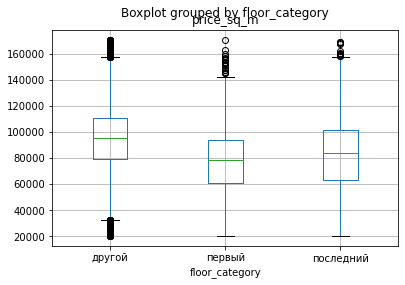

```python
data_new.boxplot(column='price_sq_m', by='floor_category');
```

Для сравнения выведем на экран общую диаграмму рахмаха цены за квадратный метр

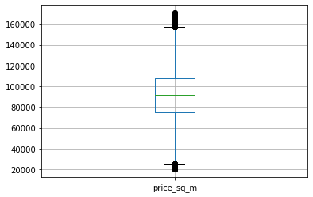

```python
data_new.boxplot(column='price_sq_m')
```

На графике видно, самая низкая медианная цена за кв м у квартир, расположенных на первом этаже, а самая высокая у квартир расположенных не на первом и не на последнем этажах. Однако также заметен большой разброс цен выше нормальных значений для квартир на первом этаже. Для квартир же не на первом и не на последнем этаже характерен разброс за пределы нормальных значений как в большую, так и в меньшую сторону. Медиана у цены квартир на другом этаже самая высокая, примерно 95 тыс за кв м, медиана у цены первого этажа примерно 79 тыс руб за кв м, медиана цены последнего этажа где-то 84 тыс руб за кв м. В целом же по таблице медианная цена 1 кв м примерно 92 тыс руб.

Выведем на экран медиану цены 1 кв м по таблице

```python
print('Медиана цены за 1 кв м ', data_new['price_sq_m'].median())
```

```
Медиана цены за 1 кв м  92088.40486867393
```

Построим сводную таблицу с медианами цены по этажам.

```python
price_floor_category = data_new.pivot_table(index = 'floor_category',
                                            values = 'price_sq_m', aggfunc = ['median', 'count'])
price_floor_category.columns = ['median_price', 'count']
price_floor_category['%_category'] = price_floor_category['count'] / price_floor_category['count'].sum() * 100
price_floor_category.sort_values(by='median_price')
```

| floor_category | median_price | count | %_category |
| --- | --- | --- | --- |
| первый | 78780.760140 | 1922 | 11.847377 |
| последний | 84126.984127 | 2054 | 12.661037 |
| другой | 95238.095238 | 12247 | 75.491586 |

Можно сделать вывод, что большая часть продаваемых квартир находится не на первом и последнем этажах (75%), Доля квартир на первом и последнем этажах почти одинаковая (12 и 13% соответственно). В целом для квартир на первом этаже характерна более низкая цена за 1 кв м, чем для квартир на последнем этаже и на других этажах. Медианная цена за 1 кв м квартиры на первом этаже на 14.5% меньше медианы в целом по таблице и на 17,4% меньше медианы цены на других этажах. Медиана цены на последнем этаже выше медианы на первом, но тоже меньше медианы в целом по таблице на 8,6% и медианы других этажей на 11,7%

#### Зависимость цены от даты размещения.

Построим диаграммы размаха для цены объявлений по дням недели.

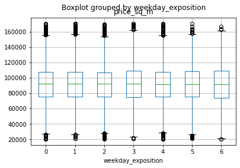

```python
data_new.boxplot(column='price_sq_m', by='weekday_exposition');
```

В целом большой разницы в медианной цене в зависимости от дня недели не видно. Нормальные распределения цен находятся в похожих пределах.

Посмотрим статистику цен по дням недели

```python
price_weekday_exposition = data_new.pivot_table(index = 'weekday_exposition',
                                            values = 'price_sq_m', aggfunc = ['median', 'count'])
price_weekday_exposition.columns = ['median_price', 'count']
price_weekday_exposition['%_weekday'] = price_weekday_exposition['count'] / price_weekday_exposition['count'].sum() * 100
price_weekday_exposition.sort_values(by='median_price')
```

| weekday_exposition | median_price | count | %_weekday |
| --- | --- | --- | --- |
| 5 | 91379.310345 | 1311 | 8.081119 |
| 4 | 91666.666667 | 2859 | 17.623128 |
| 6 | 91916.644860 | 1192 | 7.347593 |
| 1 | 92000.000000 | 2846 | 17.542995 |
| 0 | 92088.437206 | 2412 | 14.867780 |
| 3 | 92475.000000 | 2915 | 17.968317 |
| 2 | 92621.201910 | 2688 | 16.569069 |

Большее количество квартир выставляется на продажу по вторникам, четвергам и пятницам. меньше всего новых объявлений появляется по субботам и воскресеньям. Максимальное отклоненение медианы цены дня недели от медианы по таблице в большую сторону 0,6% в среду, в меньшую сторону 0,8% в субботу. Эти отклонения очень незначительные. Можно сказать, что день размещения объявления на цену не влияет.

Построим диаграмму размаха цен для месяца размещения.

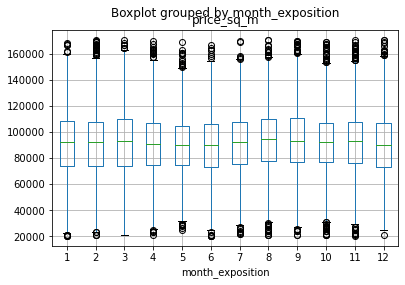

```python
data_new.boxplot(column='price_sq_m', by='month_exposition');
```

Посмотрим статистику по месяцам.

```python
price_month_exposition = data_new.pivot_table(index = 'month_exposition',
                                            values = 'price_sq_m', aggfunc = ['median', 'count'])
price_month_exposition.columns = ['median_price', 'count']
price_month_exposition['%_month'] = price_month_exposition['count'] / price_month_exposition['count'].sum() * 100
price_month_exposition.sort_values(by='median_price')
```

| month_exposition | median_price | count | %_month |
| --- | --- | --- | --- |
| 6 | 89971.014493 | 1312 | 8.087283 |
| 5 | 90307.658366 | 866 | 5.338100 |
| 12 | 90308.349146 | 1120 | 6.903779 |
| 4 | 90909.090909 | 1194 | 7.359921 |
| 10 | 92207.052262 | 1606 | 9.899525 |
| 2 | 92307.692308 | 1823 | 11.237132 |
| 7 | 92391.304348 | 1229 | 7.575664 |
| 1 | 92500.000000 | 1019 | 6.281206 |
| 3 | 92744.663217 | 1526 | 9.406398 |
| 11 | 92857.142857 | 1741 | 10.731677 |
| 9 | 93380.614657 | 1477 | 9.104358 |
| 8 | 94250.319920 | 1310 | 8.074955 |

Таблица подтверждает выводы, сделанные на основе графика. Самая высокая цены за 1 кв м характерны для августа, медиана выше медианы в целом по таблице на 2,4%. Самая низкие цена за 1 кв м в июне - медиана цен в июне меньше медианы в целом по таблице на 2,3%. Мы не знаем за какой период собраны данные в таблице, возможно там есть неполное количество месяцев по каким-то годам, но на основе имеющихся данных можно сказать, что наибольшее число квартир выставляется на продажу в феврале и ноябре, меньше все квартиры продают в мае и январе.

Построим диаграмму размаха цен для года размещения.

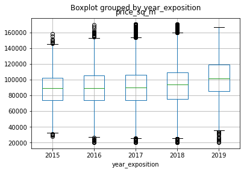

```python
data_new.boxplot(column='price_sq_m', by='year_exposition');
```

По диаграмме с годами прослеживается заметный рост цен на недвижимость, особенно явно это видно по 2018, 2019 годам. Медиана сместилась с примерно 94 тыс в 2018 на 102 тыс в 2019 г.

Посмотрим статистику

```python
price_year_exposition = data_new.pivot_table(index = 'year_exposition',
                                            values = 'price_sq_m', aggfunc = ['median', 'count'])
price_year_exposition.columns = ['median_price', 'count']
price_year_exposition['%_year'] = price_year_exposition['count'] / price_year_exposition['count'].sum() * 100
price_year_exposition.sort_values(by='median_price')
```

| year_exposition | median_price | count | %_year |
| --- | --- | --- | --- |
| 2015 | 88888.888889 | 395 | 2.434815 |
| 2016 | 89185.887047 | 1778 | 10.959749 |
| 2017 | 90000.000000 | 6562 | 40.448746 |
| 2018 | 93827.160494 | 6553 | 40.393269 |
| 2019 | 101875.000000 | 935 | 5.763422 |

В целом таблица подтверждает выводы по графику. Цены на недвижимость с годами растут. И самая высокая медианная цена в 2019 г., она выше медианы по таблице на 10,6%, а самая низкая в 2015, она ниже медианы по таблице на 3,5%. Рост цен в 2019 г. был максимальным за весь период выборки. Если в 2018 году медианная цена по сравнению с 2017 г. выросла на 4,2%, то в 2019 по сравнению с 2018 уже на 8,6%.

Еще можно отметить резкое увеличение количества объявлений, размещаемых на сайте начиная с 2017 г. Возможно это связано с разитием данного сервиса, а не с увеличением в целом количества продаваемых квартир.

#### Цены в десяти населенных пунктах с наибольшим числом объявлений.

Определим населенные пункты с наибольшим числом объявлений Посчитаем среднюю цену и количество объявлений, сгруппировав таблицу по 10 населенным пунктам из списка, отсортируем по возрастанию средней цены.

```python
data_new_10 = data_new['locality_name'].value_counts().head(10).index

# посчитаем среднюю цену, сгруппировав таблицу по 10 населенным пунктам из списка, отсортируем по возрастанию средней цены.
data_new[data_new['locality_name'].isin(data_new_10)].groupby('locality_name').agg({'price_sq_m':'mean','locality_name':'count'}).sort_values(by='price_sq_m')
```

| locality_name | price_sq_m | locality_name |
| --- | --- | --- |
| Выборг | 57076.746518 | 173 |
| Всеволожск | 66640.321379 | 295 |
| Гатчина | 68362.832675 | 227 |
| Колпино | 74789.576690 | 278 |
| Шушары | 77901.074813 | 383 |
| Мурино | 85984.790839 | 514 |
| Парголово | 89336.954129 | 287 |
| Кудрово | 94570.435573 | 404 |
| Пушкин | 100116.414897 | 242 |
| Санкт-Петербург | 103725.311308 | 10311 |

В десяти населеннных пунктах с наибольшим количеством объявлений самая высокая цена квартиры за 1 кв м в Санкт-Петербурге - она выше средней в целом по таблице на 13,4% (средняя цена кв м по таблице 91493руб.), самая низкая средняя цена квадратного метра в Выборге - она ниже средней по таблице на 37,6%. В целом разница между самой низкой средней ценой в Выборге и самой высокой в Санкт-Петербурге составляет 81%.

#### Изучение квартир в центре Санкт-Петербурга.

Для того, чтобы определить центральную зону Санкт-петербурга, построим график изменения средней цены за 1 кв м для каждого км удаленности от центра.

Добавим к таблице столбец с округленным расстоянием до центра в км

```python
data_new['cityCenters_nearest_km'] = (data_new['cityCenters_nearest'] / 1000).astype('int')
```

Построим график средней цены за кв м по Санкт-Петербургу в зависимости от расстояния от центра, сгруппировав данные по расстоянию от центра в км

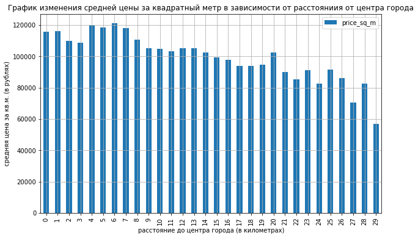

```python
(
    data_new.query('locality_name == "Санкт-Петербург"')
    .groupby('cityCenters_nearest_km').agg({'price_sq_m': 'mean'}).plot(kind='bar', grid=True, figsize=(10,6))
);
plt.title('График изменения средней цены за квадратный метр в зависимости от расстояниия от центра города')
plt.ylabel('средняя цена за кв.м. (в рублях)')
plt.xlabel('расстояние до центра города (в километрах)')
```

Цена кв м растет с уменьшением расстояния до центра. Наиболее высокие показатели средней цены за 1 кв м начинаются с расстояния 8 км от центра города. Определим радиус централной зоны равным 8 км.

Соберем объявления по центру города в отдельный датафрейм. Посмотрим информацию по нему.

```python
data_city_center = data_new.query('cityCenters_nearest_km <= 8')
data_city_center.describe().T
```

|  | count | mean | std | min | 25% | 50% | 75% | max |
| --- | --- | --- | --- | --- | --- | --- | --- | --- |
| total_images | 1600.0 | 9.218125e+00 | 5.574380e+00 | 0.000000e+00 | 5.000000e+00 | 9.000000e+00 | 1.300000e+01 | 3.200000e+01 |
| last_price | 1600.0 | 7.114592e+06 | 2.895619e+06 | 1.686000e+06 | 4.966752e+06 | 6.600000e+06 | 8.750000e+06 | 1.800000e+07 |
| total_area | 1600.0 | 6.186624e+01 | 2.188464e+01 | 1.320000e+01 | 4.400000e+01 | 5.895000e+01 | 7.800000e+01 | 1.142000e+02 |
| rooms | 1600.0 | 2.163750e+00 | 9.103317e-01 | 1.000000e+00 | 1.000000e+00 | 2.000000e+00 | 3.000000e+00 | 6.000000e+00 |
| ceiling_height | 1600.0 | 2.690706e+00 | 8.787215e-02 | 2.400000e+00 | 2.700000e+00 | 2.700000e+00 | 2.700000e+00 | 2.920000e+00 |
| floors_total | 1600.0 | 8.692500e+00 | 5.089979e+00 | 2.000000e+00 | 5.000000e+00 | 6.000000e+00 | 1.100000e+01 | 2.800000e+01 |
| living_area | 1600.0 | 3.582694e+01 | 1.536063e+01 | 6.000000e+00 | 2.297500e+01 | 3.380000e+01 | 4.635670e+01 | 8.700000e+01 |
| floor | 1600.0 | 4.761250e+00 | 3.547832e+00 | 1.000000e+00 | 2.000000e+00 | 4.000000e+00 | 6.000000e+00 | 2.300000e+01 |
| kitchen_area | 1587.0 | 1.076091e+01 | 4.886242e+00 | 2.000000e+00 | 7.542857e+00 | 9.990000e+00 | 1.258304e+01 | 5.570000e+01 |
| balcony | 1600.0 | 4.100000e-01 | 8.245149e-01 | 0.000000e+00 | 0.000000e+00 | 0.000000e+00 | 1.000000e+00 | 5.000000e+00 |
| airports_nearest | 1600.0 | 2.566431e+04 | 6.486196e+03 | 1.113500e+04 | 2.091825e+04 | 2.469100e+04 | 3.008200e+04 | 4.475400e+04 |
| cityCenters_nearest | 1600.0 | 5.863882e+03 | 2.051297e+03 | 3.990000e+02 | 4.411250e+03 | 5.879000e+03 | 7.734000e+03 | 8.990000e+03 |
| parks_around3000 | 1600.0 | 8.012500e-01 | 8.468747e-01 | 0.000000e+00 | 0.000000e+00 | 1.000000e+00 | 1.000000e+00 | 3.000000e+00 |
| parks_nearest | 904.0 | 5.062588e+02 | 3.630786e+02 | 9.000000e+00 | 3.020000e+02 | 4.540000e+02 | 6.130000e+02 | 2.532000e+03 |
| ponds_around3000 | 1600.0 | 1.144375e+00 | 1.011395e+00 | 0.000000e+00 | 0.000000e+00 | 1.000000e+00 | 2.000000e+00 | 3.000000e+00 |
| ponds_nearest | 1110.0 | 4.976793e+02 | 2.573248e+02 | 2.200000e+01 | 2.950000e+02 | 4.850000e+02 | 6.837500e+02 | 1.207000e+03 |
| days_exposition | 1600.0 | 1.319550e+02 | 1.233798e+02 | 3.000000e+00 | 3.800000e+01 | 9.000000e+01 | 1.902500e+02 | 5.090000e+02 |
| price_sq_m | 1600.0 | 1.158687e+05 | 2.424674e+04 | 2.625000e+04 | 9.777333e+04 | 1.133866e+05 | 1.340620e+05 | 1.703125e+05 |
| ratio_living_total_area | 1600.0 | 5.718078e-01 | 1.054601e-01 | 1.935484e-01 | 5.084971e-01 | 5.851296e-01 | 6.444444e-01 | 9.310345e-01 |
| ratio_kitchen_total_area | 1587.0 | 1.821098e-01 | 7.252975e-02 | 6.060606e-02 | 1.293988e-01 | 1.610738e-01 | 2.183081e-01 | 5.605263e-01 |
| weekday_exposition | 1600.0 | 2.608125e+00 | 1.754703e+00 | 0.000000e+00 | 1.000000e+00 | 3.000000e+00 | 4.000000e+00 | 6.000000e+00 |
| month_exposition | 1600.0 | 6.755625e+00 | 3.400645e+00 | 1.000000e+00 | 4.000000e+00 | 7.000000e+00 | 1.000000e+01 | 1.200000e+01 |
| year_exposition | 1600.0 | 2.017253e+03 | 8.509973e-01 | 2.015000e+03 | 2.017000e+03 | 2.017000e+03 | 2.018000e+03 | 2.019000e+03 |
| cityCenters_nearest_km | 1600.0 | 5.376875e+00 | 2.050602e+00 | 0.000000e+00 | 4.000000e+00 | 5.000000e+00 | 7.000000e+00 | 8.000000e+00 |

В таблицу попало 1600 объявлений, с квартирами, расположенными в центре города - это примерно 10% объявлений из таблицы без выбросов. Цена квартир в центре варируется от 1,69 млн до 18 млн р, цена за кв м от 26 тыс до 170 тыс (очень большой разброс). В среднем квартиры в центре продаются за 7,11 млн руб., средняя цена за 1 кв м 115,9 тыс руб.

Средняя площадь продаваемых квартир 61,9 кв м, максимальная 114 кв м, большая часть картир 2-х комнатные.

В среднем квартиры в центре продаются за 132 дня, хотя медиана составляет 90 дней (среднюю повышает большое максимальное количество дней в продаже 509).

**Площадь квартир в центре**

Построим гистограмму для показателя площадь квартир в центре города.

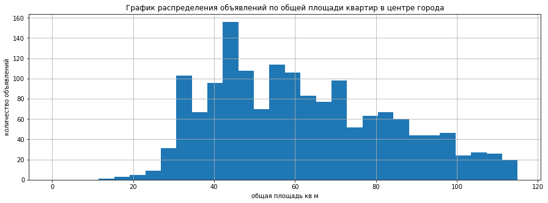

```python
data_city_center['total_area'].plot(kind='hist', range=(0, 115),bins=30, figsize=(15,5), grid=True)
plt.title('График распределения объявлений по общей площади квартир в центре города')
plt.ylabel('количество объявлений')
plt.xlabel('общая площадь кв м')
```

Можно увидеть, что как и в целом по выборке большую часть продаваемых квартир в центре составляют квартиры площадью от 30 до 70 кв м. Также как и во всей таблице выделяются квартиры площадью около 30-35 кв м - более 100 объявлений (6%) и квартиры площадью примерно 45 кв м - больше 150 объявлений (9% как и по всей выборке). Еще можно отметить в центре довольно таки существенную долю квартир площадью около 70 кв м (около 100 объявлений - 6%) их почти столько же, сколько квартир с площадью 30 кв м. В целом глядя на график, можно сказать, что доля продающихся в центре города квартир с площадью от 60 кв м и выш больше чем в общей выюорке.

**Число комнат у проданных квартир в центре города**

Построим гистограмму для показателя количество комнат у квартир в центре города.

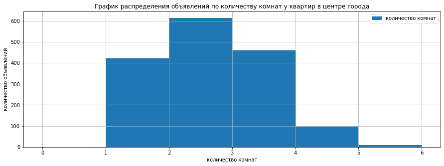

```python
data_city_center['rooms'].plot(kind='hist', range=(0, 6),bins=6, figsize=(15,5), grid=True,label='количество комнат', legend=True)
plt.title('График распределения объявлений по количеству комнат у квартир в центре города')
plt.ylabel('количество объявлений')
plt.xlabel('количество комнат')
```

В отличии от общей выборки, где большую часть продаваемых квартир составляют однокомнатные, на втором месте двухкомнатные, а доля трехкомнатных квартир существенно ниже, в центре большинство продаваемых квартир - двухкомнатные (больее 600 объявлений - почти 38%), на втором месте 3-х комнатные - более 450 объявлений (28%), и только на третьем однокомнатные - чуть больше 400 объявлений (25%). В общих данных доля 1 комнатных квартир была около 35%, а трехкомнатных примерно 25%.

Эти данные подтверждают сделанный выше вывод о том, что доля квартир с большей площадью в центре города выше, чем в целом по выборке.

**Высота потолков у квартир в центре города**

Построим гистограмму для этого показателя.

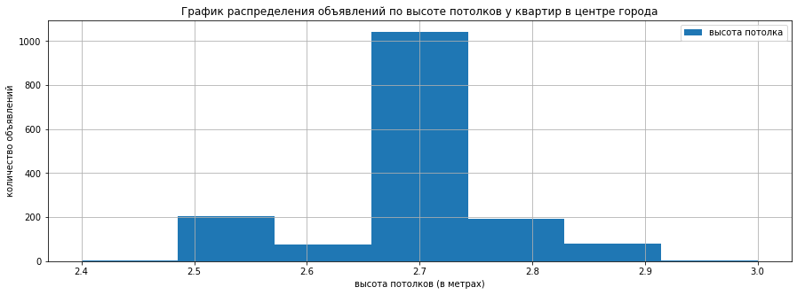

```python
data_city_center['ceiling_height'].plot(kind='hist', range=(2.4, 3),bins=7, figsize=(15,5), grid=True, label='высота потолка', legend=True)
plt.title('График распределения объявлений по высоте потолков у квартир в центре города')
plt.ylabel('количество объявлений')
plt.xlabel('высота потолков (в метрах)')
```

Основная высота потолков у квартир в центре города 2,7 м (таких больше 1000- почти 63%). В целом по таблице квартир с высотой потолков около 2,7 м тоже больше всего , но их доля меньше (около 40%). С квартирами высота потолков в которых ниже чем 2,7 в центре всего около 300 объявлений (19%), а в целом по общим данным их доля около 27%.

**Цена квартир в центре Санкт-Петербурга**

Построим также гистограмму с ценой за квадратный метр продаваемых в центре квартир.

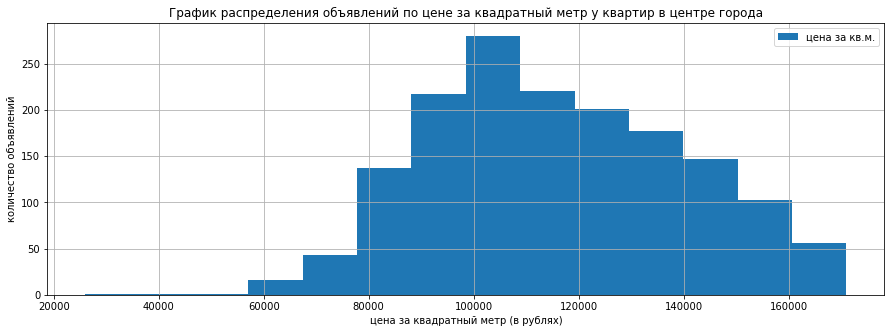

```python
data_city_center['price_sq_m'].plot(kind='hist', range=(26000, 171000),bins=14, figsize=(15,5), grid=True, label='цена за кв.м.' ,legend=True)
plt.title('График распределения объявлений по цене за квадратный метр у квартир в центре города')
plt.ylabel('количество объявлений')
plt.xlabel('цена за квадратный метр (в рублях)')
```

В основной части объявлений в общей выборке цена квадратного метра от 80 до 105 тыс руб. В центре же цена квадратного метра большинства квартир находится в диапазоне 90-140тыс (причем значений болше в более высоком диапазоне, количество объявлений с увеличением цены уменьшается постепенно). Квартир с ценой менее 80 тыс за кв м чуть больше 50 (3%). Чаще всего в объявлениях о продаже квартир в центре города встречается цена 100-110 тыс руб за кв м - около 290 объявлений (18%). В целом по выборки таких объявлений около 7%, а чаще всего встречается цена 95-100 тыс р за кв м, что на 10 тыс р меньше, цены в центре.

**Время продажи квартир в центре**

Рассмотри гистограмму с временем продаж квартир в центре Санкт-петербурга.

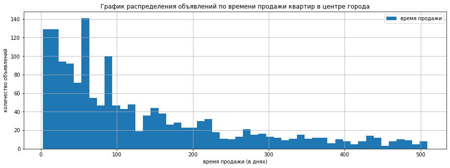

```python
data_city_center['days_exposition'].plot(kind='hist', range=(3, 509),bins=50, figsize=(15,5), grid=True, label='время продажи' ,legend=True)
plt.title('График распределения объявлений по времени продажи квартир в центре города')
plt.ylabel('количество объявлений')
plt.xlabel('время продажи (в днях)')
```